Joana Gonçalves Pg49835, Bruno Sá Pg49832, Gonçalo Cardoso Pg49834, Luís Ferreira Pg49840

11/06/23

[figure not shown]

# 1 Explicação dos dados, a sua origem e relevância

O National Cancer Institute (NCI) dos Estados Unidos gere o Genomic Data Commons (GDC), um repositório de dados que fornece acesso a dados genómicos e clínicos de vários projetos de pesquisa sobre vários tipos de cancro , incluindo o TCGA. O GDC fornece uma plataforma para bioinformáticos e clínicos acederem e analisarem os dados do TCGA - GBM juntamente com dados de outros estudos do TCGA e outros projetos.

Depois de analisarmos várias hipoteses de estudo para este trabalho decidimos analisar os dados recolhidos no seguinte [ensaio clínico](https://portal.gdc.cancer.gov/projects/TCGA-GBM). O TCGA - GBM é um estudo genómico que faz parte do projeto TCGA (The Cancer Genome Atlas ) e foca-se num tipo agressivo de cancro cerebral conhecido como glioblastoma multiforme (GBM) .

O objetivo do TCGA - GBM é entender as alterações genéticas e moleculares que ocorrem nesse tipo de cancro para desenvolver novas terapias e tratamentos mais eficazes .

As informações para o TCGA-GBM foram coletadas de amostras de tecido tumoral retiradas de pacientes com GBM , juntamente com detalhes clínicos como idade, sexo e tempo de sobrevivência. O estudo utilizou várias técnicas de análise genómica , como sequenciamento de DNA e RNA , para encontrar alterações genéticas , alterações no número de cópias de genes e expressão diferencial de genes.

Os dados do TCGA-GBM são extremamente importantes para a compreensão do glioblastoma multiforme e possibilitarão bioinformáticos e investigadores encontrar novos alvos terapêuticos para o tratamento desse tipo de cancro. Além disso, esses dados poderão ser usados para desenvolver novas terapias, identificar indicadores e melhorar o diagnóstico e tratamento de GBM .

# 2 Import das Librarys

```r
library(TCGAbiolinks)
library(SummarizedExperiment)
library(DESeq2)
library(ggplot2)
library(edgeR)
library(limma)
library(Glimma)
library(gplots)
library(org.Mm.eg.db)
library(RColorBrewer)
library(car)
library(genefilter)
library(summarytools)
library(org.Hs.eg.db)
library(clusterProfiler)
library(pheatmap)
library(caret)
library(cluster)
library(class)
library(e1071)
library(party)
library(randomForest)
library(nnet)
library(Rtsne)
```

# 3 Recolha dos dados: Importação e Carregamento dados de Expressão/Metadados e Verificação do seu conteúdo e dimensão

## 3.1 Importação de dados de Expressão/Metadados

```r
proj = "TCGA-GBM"
query = GDCquery(
  project = proj,
  data.category = "Transcriptome Profiling",
  data.type = "Gene Expression Quantification",
  workflow.type = "STAR - Counts"
)


GDCdownload(query)
```

```r
gbm= GDCprepare(query)
```

[output not shown]

[output cut: 98 more lines]

[output not shown]

```r
gbm
```

```
## class: RangedSummarizedExperiment
## dim: 60660 175
## metadata(1): data_release
## assays(6): unstranded stranded_first ... fpkm_unstrand fpkm_uq_unstrand
## rownames(60660): ENSG00000000003.15 ENSG00000000005.6 ...
##   ENSG00000288674.1 ENSG00000288675.1
## rowData names(10): source type ... hgnc_id havana_gene
## colnames(175): TCGA-06-0156-01A-03R-1849-01
##   TCGA-06-0675-11A-32R-A36H-07 ... TCGA-32-1980-01A-01R-1850-01
##   TCGA-06-5412-01A-01R-1849-01
## colData names(107): barcode patient ...
##   paper_Telomere.length.estimate.in.blood.normal..Kb.
##   paper_Telomere.length.estimate.in.tumor..Kb.
```

## 3.2 Importação dados dos Dados clinicos

```r
query_clin = GDCquery(project = "TCGA-GBM",
                      data.category = "Clinical",
                      data.type = "Clinical Supplement",
                      data.format = "BCR Biotab")

GDCdownload(query_clin)

clinical.GBM = GDCprepare(query_clin)
clinical.GBM
```

```
## $clinical_omf_v4.0_gbm
## # A tibble: 5 × 30
##   bcr_patient_uuid              bcr_patient_barcode bcr_omf_barcode bcr_omf_uuid
##   <chr>                         <chr>               <chr>           <chr>
## 1 bcr_patient_uuid              bcr_patient_barcode bcr_omf_barcode bcr_omf_uuid
## 2 CDE_ID:                       CDE_ID:2003301      CDE_ID:         CDE_ID:
## 3 a795a841-9fd6-4eac-b871-a8c7… TCGA-06-0209        TCGA-06-0209-O… DC63B730-14…
## 4 7a4c0a14-ac97-4c2b-a9cc-68cb… TCGA-06-6391        TCGA-06-6391-O… 8EEF8BA7-9B…
## 5 B0406065-73BD-4370-8133-7A1C… TCGA-19-A6J4        TCGA-19-A6J4-O… 9A46D1F5-F1…
## # ℹ 26 more variables: form_completion_date <chr>, malignancy_type <chr>,
## #   other_malignancy_dx_days_to <chr>, surgery_indicator <chr>,
## #   other_malignancy_surgery_type <chr>,
## #   other_malignancy_surgery_days_to <chr>,
## #   pharmaceutical_therapy_indicator <chr>,
## #   pharmaceutical_therapy_extent <chr>,
## #   pharmaceutical_therapy_drug_name <chr>, …
##
## $clinical_drug_gbm
## # A tibble: 1,507 × 28
##    bcr_patient_uuid           bcr_patient_barcode bcr_drug_barcode bcr_drug_uuid
##    <chr>                      <chr>               <chr>            <chr>
##  1 bcr_patient_uuid           bcr_patient_barcode bcr_drug_barcode bcr_drug_uuid
##  2 CDE_ID:                    CDE_ID:2003301      CDE_ID:          CDE_ID:
##  3 30a1fe5e-5b12-472c-aa86-c… TCGA-02-0001        TCGA-02-0001-D2… d3b26cd2-fb6…
##  4 30a1fe5e-5b12-472c-aa86-c… TCGA-02-0001        TCGA-02-0001-D2… 2a1a1dd1-cc4…
##  5 30a1fe5e-5b12-472c-aa86-c… TCGA-02-0001        TCGA-02-0001-D2… a1cf26d0-3ef…
##  6 30a1fe5e-5b12-472c-aa86-c… TCGA-02-0001        TCGA-02-0001-D2… 5a058cdd-9be…
##  7 df3c1d61-79c1-43e9-971a-8… TCGA-02-0003        TCGA-02-0003-D2… 002b8484-017…
##  8 3ac8f759-2df0-4ef5-913f-c… TCGA-02-0004        TCGA-02-0004-D2… e339b977-467…
##  9 3ac8f759-2df0-4ef5-913f-c… TCGA-02-0004        TCGA-02-0004-D2… 2e973179-037…
## 10 98714d95-b62e-4f34-9cd1-9… TCGA-02-0006        TCGA-02-0006-D2… 320ce724-3c1…
## # ℹ 1,497 more rows
## # ℹ 24 more variables: form_completion_date <chr>,
## #   pharmaceutical_therapy_drug_name <chr>,
## #   clinical_trial_drug_classification <chr>,
## #   pharmaceutical_therapy_type <chr>, pharmaceutical_tx_started_days_to <chr>,
## #   pharmaceutical_tx_ongoing_indicator <chr>,
## #   pharmaceutical_tx_ended_days_to <chr>, treatment_best_response <chr>, …
##
## $clinical_nte_gbm
```

[output cut: 105 more lines]

```
## #   radiation_adjuvant_fractions_total <chr>,
## #   radiation_therapy_started_days_to <chr>,
## #   radiation_therapy_ongoing_indicator <chr>, …
##
## attr(,"split_type")
## [1] "array"
## attr(,"split_labels")
##   X1
## 1  1
## 2  2
## 3  3
## 4  4
## 5  5
## 6  6
## 7  7
```

## 3.3 Vizualização dos dados e Verificação do seu conteúdo e dimensão

**Visualização dos objetos da class RangedSummarizedExperiment**

```r
gbm
```

```
## class: RangedSummarizedExperiment
## dim: 60660 175
## metadata(1): data_release
## assays(6): unstranded stranded_first ... fpkm_unstrand fpkm_uq_unstrand
## rownames(60660): ENSG00000000003.15 ENSG00000000005.6 ...
##   ENSG00000288674.1 ENSG00000288675.1
## rowData names(10): source type ... hgnc_id havana_gene
## colnames(175): TCGA-06-0156-01A-03R-1849-01
##   TCGA-06-0675-11A-32R-A36H-07 ... TCGA-32-1980-01A-01R-1850-01
##   TCGA-06-5412-01A-01R-1849-01
## colData names(107): barcode patient ...
##   paper_Telomere.length.estimate.in.blood.normal..Kb.
##   paper_Telomere.length.estimate.in.tumor..Kb.
```

**Visualização dos dados presentes na assay**

```r
assayNames(gbm)
```

```
## [1] "unstranded"       "stranded_first"   "stranded_second"  "tpm_unstrand"
## [5] "fpkm_unstrand"    "fpkm_uq_unstrand"
```

**Vizualização dos 5 primeiros e 5 últimos genes**

```r
rowRanges(gbm)
```

```
## GRanges object with 60660 ranges and 10 metadata columns:
##                      seqnames              ranges strand |   source     type
##                         <Rle>           <IRanges>  <Rle> | <factor> <factor>
##   ENSG00000000003.15     chrX 100627108-100639991      - |   HAVANA     gene
##    ENSG00000000005.6     chrX 100584936-100599885      + |   HAVANA     gene
##   ENSG00000000419.13    chr20   50934867-50958555      - |   HAVANA     gene
##   ENSG00000000457.14     chr1 169849631-169894267      - |   HAVANA     gene
##   ENSG00000000460.17     chr1 169662007-169854080      + |   HAVANA     gene
##                  ...      ...                 ...    ... .      ...      ...
##    ENSG00000288669.1    chr19     7728958-7745662      - |   HAVANA     gene
##    ENSG00000288670.1     chr1 161368022-161371964      + |   HAVANA     gene
##    ENSG00000288671.1    chr19   42215133-42232149      - |   HAVANA     gene
##    ENSG00000288674.1     chr1 226870184-226987545      + |   HAVANA     gene
##    ENSG00000288675.1    chr11       797511-799190      + |   HAVANA     gene
##                          score     phase            gene_id      gene_type
##                      <numeric> <integer>        <character>    <character>
##   ENSG00000000003.15        NA      <NA> ENSG00000000003.15 protein_coding
##    ENSG00000000005.6        NA      <NA>  ENSG00000000005.6 protein_coding
##   ENSG00000000419.13        NA      <NA> ENSG00000000419.13 protein_coding
##   ENSG00000000457.14        NA      <NA> ENSG00000000457.14 protein_coding
##   ENSG00000000460.17        NA      <NA> ENSG00000000460.17 protein_coding
##                  ...       ...       ...                ...            ...
##    ENSG00000288669.1        NA      <NA>  ENSG00000288669.1 protein_coding
##    ENSG00000288670.1        NA      <NA>  ENSG00000288670.1         lncRNA
##    ENSG00000288671.1        NA      <NA>  ENSG00000288671.1 protein_coding
##    ENSG00000288674.1        NA      <NA>  ENSG00000288674.1 protein_coding
##    ENSG00000288675.1        NA      <NA>  ENSG00000288675.1 protein_coding
##                        gene_name       level     hgnc_id          havana_gene
##                      <character> <character> <character>          <character>
##   ENSG00000000003.15      TSPAN6           2  HGNC:11858 OTTHUMG00000022002.2
##    ENSG00000000005.6        TNMD           2  HGNC:17757 OTTHUMG00000022001.2
##   ENSG00000000419.13        DPM1           2   HGNC:3005 OTTHUMG00000032742.2
##   ENSG00000000457.14       SCYL3           2  HGNC:19285 OTTHUMG00000035941.6
##   ENSG00000000460.17    C1orf112           2  HGNC:25565 OTTHUMG00000035821.9
##                  ...         ...         ...         ...                  ...
##    ENSG00000288669.1  AC008763.4           2        <NA>                 <NA>
##    ENSG00000288670.1  AL592295.6           2        <NA>                 <NA>
##    ENSG00000288671.1  AC006486.3           2        <NA>                 <NA>
##    ENSG00000288674.1  AL391628.1           2        <NA>                 <NA>
##    ENSG00000288675.1  AP006621.6           2        <NA> OTTHUMG00000189301.4
##   -------
##   seqinfo: 25 sequences from an unspecified genome; no seqlengths
```

**Dimensão e Classe do Objeto**

```r
dim(gbm)
```

```
## [1] 60660   175
```

```r
class(gbm)
```

```
## [1] "RangedSummarizedExperiment"
## attr(,"package")
## [1] "SummarizedExperiment"
```

A partir desta análise percebemos que o data_rna_GBM tem 60660 linhas (que correspondem a genes) e 175 colunas (que correspondem a amostras) para além disso, é um objeto da classe RangedSummarizedExperiment, que faz parte do pacote SummarizedExperiment.

## 3.4 Matrizes counts

```r
gbm_assay = round(assays(gbm)[["unstranded"]])
```

# 4 Estatistica univariada

## 4.1 Sumarização dos dados

```r
print(dfSummary(gbm_assay, style = 'grid', graph.magnif = 1, valid.col = FALSE,
                max.distinct.values = 5, col.widths = c(100, 200, 200, 350, 500, 250),
                dfSummary.silent  = TRUE, headings = FALSE, justify = 'l')
      , method = 'render', max.tbl.height = 500)
```

```
## gbm_assay was converted to a data frame
```

| **No** | **Variable** | **Stats / Values** | **Freqs (% of Valid)** | **Graph** | **Missing** |
| --- | --- | --- | --- | --- | --- |
| 1 | TCGA-06-0156-01A-03R-1849-01 [numeric] | Mean (sd) : 684.6 (5460.7) min ≤ med ≤ max: 0 ≤ 2 ≤ 552781 IQR (CV) : 92 (8) | 5255 distinct values |  | 0 (0.0%) |
| 2 | TCGA-06-0675-11A-32R-A36H-07 [numeric] | Mean (sd) : 873.5 (9409.7) min ≤ med ≤ max: 0 ≤ 1 ≤ 1236775 IQR (CV) : 77 (10.8) | 5719 distinct values |  | 0 (0.0%) |
| 3 | TCGA-32-4213-01A-01R-1850-01 [numeric] | Mean (sd) : 309.9 (3715) min ≤ med ≤ max: 0 ≤ 1 ≤ 481402 IQR (CV) : 23 (12) | 3200 distinct values |  | 0 (0.0%) |
| 4 | TCGA-32-2634-01A-01R-1850-01 [numeric] | Mean (sd) : 924.4 (6238.2) min ≤ med ≤ max: 0 ≤ 2 ≤ 618733 IQR (CV) : 127 (6.7) | 6345 distinct values |  | 0 (0.0%) |
| 5 | TCGA-06-0187-01A-01R-1849-01 [numeric] | Mean (sd) : 777.5 (8331.7) min ≤ med ≤ max: 0 ≤ 1 ≤ 1263955 IQR (CV) : 48 (10.7) | 5414 distinct values |  | 0 (0.0%) |
| 6 | TCGA-12-3652-01A-01R-1849-01 [numeric] | Mean (sd) : 646.4 (5338) min ≤ med ≤ max: 0 ≤ 1 ≤ 506501 IQR (CV) : 41 (8.3) | 4842 distinct values |  | 0 (0.0%) |
| 7 | TCGA-06-0156-01A-02R-1849-01 [numeric] | Mean (sd) : 684.5 (5563.2) min ≤ med ≤ max: 0 ≤ 2 ≤ 587618 IQR (CV) : 96 (8.1) | 5342 distinct values |  | 0 (0.0%) |
| 8 | TCGA-26-5134-01A-01R-1850-01 [numeric] | Mean (sd) : 191.7 (2633) min ≤ med ≤ max: 0 ≤ 1 ≤ 456445 IQR (CV) : 25 (13.7) | 2457 distinct values |  | 0 (0.0%) |
| 9 | TCGA-32-2638-01A-01R-1850-01 [numeric] | Mean (sd) : 965.9 (7639.9) min ≤ med ≤ max: 0 ≤ 1 ≤ 662905 IQR (CV) : 80 (7.9) | 6156 distinct values |  | 0 (0.0%) |
| 10 | TCGA-06-0882-01A-01R-1849-01 [numeric] | Mean (sd) : 805.7 (8012.7) min ≤ med ≤ max: 0 ≤ 2 ≤ 872948 IQR (CV) : 92 (9.9) | 5610 distinct values |  | 0 (0.0%) |
| 11 | TCGA-06-AABW-11A-31R-A36H-07 [numeric] | Mean (sd) : 744.1 (7045.6) min ≤ med ≤ max: 0 ≤ 1 ≤ 885449 IQR (CV) : 59 (9.5) | 5283 distinct values |  | 0 (0.0%) |
| 12 | TCGA-06-0168-01A-01R-1849-01 [numeric] | Mean (sd) : 193.5 (2071.6) min ≤ med ≤ max: 0 ≤ 0 ≤ 193316 IQR (CV) : 20 (10.7) | 2501 distinct values |  | 0 (0.0%) |
| 13 | TCGA-28-5209-01A-01R-1850-01 [numeric] | Mean (sd) : 838 (5461.4) min ≤ med ≤ max: 0 ≤ 1 ≤ 521410 IQR (CV) : 51 (6.5) | 5952 distinct values |  | 0 (0.0%) |
| 14 | TCGA-06-0221-02A-11R-2005-01 [numeric] | Mean (sd) : 711.8 (4370.8) min ≤ med ≤ max: 0 ≤ 2 ≤ 427984 IQR (CV) : 81 (6.1) | 5642 distinct values |  | 0 (0.0%) |
| 15 | TCGA-14-1034-01A-01R-1849-01 [numeric] | Mean (sd) : 578.2 (5179.5) min ≤ med ≤ max: 0 ≤ 0 ≤ 791139 IQR (CV) : 36 (9) | 4834 distinct values |  | 0 (0.0%) |
| 16 | TCGA-41-2572-01A-01R-1850-01 [numeric] | Mean (sd) : 655.2 (6301.2) min ≤ med ≤ max: 0 ≤ 1 ≤ 570525 IQR (CV) : 51 (9.6) | 4932 distinct values |  | 0 (0.0%) |
| 17 | TCGA-06-0184-01A-01R-1849-01 [numeric] | Mean (sd) : 823.7 (7918.8) min ≤ med ≤ max: 0 ≤ 1 ≤ 680265 IQR (CV) : 64 (9.6) | 5530 distinct values |  | 0 (0.0%) |
| 18 | TCGA-28-5204-01A-01R-1850-01 [numeric] | Mean (sd) : 723.6 (4359.9) min ≤ med ≤ max: 0 ≤ 1 ≤ 401086 IQR (CV) : 51 (6) | 5606 distinct values |  | 0 (0.0%) |
| 19 | TCGA-32-5222-01A-01R-1850-01 [numeric] | Mean (sd) : 838.3 (6167.8) min ≤ med ≤ max: 0 ≤ 1 ≤ 492608 IQR (CV) : 65 (7.4) | 5698 distinct values |  | 0 (0.0%) |
| 20 | TCGA-12-0616-01A-01R-1849-01 [numeric] | Mean (sd) : 478.8 (4378.2) min ≤ med ≤ max: 0 ≤ 1 ≤ 504062 IQR (CV) : 44 (9.1) | 4150 distinct values |  | 0 (0.0%) |
| 21 | TCGA-15-0742-01A-01R-1850-01 [numeric] | Mean (sd) : 703 (6060.3) min ≤ med ≤ max: 0 ≤ 1 ≤ 571903 IQR (CV) : 57 (8.6) | 5284 distinct values |  | 0 (0.0%) |
| 22 | TCGA-06-0749-01A-01R-1849-01 [numeric] | Mean (sd) : 737.5 (10843.6) min ≤ med ≤ max: 0 ≤ 1 ≤ 2031597 IQR (CV) : 86 (14.7) | 5177 distinct values |  | 0 (0.0%) |
| 23 | TCGA-06-0157-01A-01R-1849-01 [numeric] | Mean (sd) : 815.2 (9566.8) min ≤ med ≤ max: 0 ≤ 1 ≤ 1730209 IQR (CV) : 78 (11.7) | 5631 distinct values |  | 0 (0.0%) |
| 24 | TCGA-16-1045-01B-01R-1850-01 [numeric] | Mean (sd) : 611.6 (6072.3) min ≤ med ≤ max: 0 ≤ 1 ≤ 792500 IQR (CV) : 58.2 (9.9) | 4830 distinct values |  | 0 (0.0%) |
| 25 | TCGA-06-5856-01A-01R-1849-01 [numeric] | Mean (sd) : 812.7 (5986.2) min ≤ med ≤ max: 0 ≤ 2 ≤ 583617 IQR (CV) : 84 (7.4) | 5786 distinct values |  | 0 (0.0%) |
| 26 | TCGA-32-2615-01A-01R-1850-01 [numeric] | Mean (sd) : 925.8 (10238) min ≤ med ≤ max: 0 ≤ 2 ≤ 1715636 IQR (CV) : 107 (11.1) | 5986 distinct values |  | 0 (0.0%) |
| 27 | TCGA-19-2620-01A-01R-1850-01 [numeric] | Mean (sd) : 473.8 (5856.4) min ≤ med ≤ max: 0 ≤ 1 ≤ 769954 IQR (CV) : 46 (12.4) | 4101 distinct values |  | 0 (0.0%) |
| 28 | TCGA-06-0680-11A-32R-A36H-07 [numeric] | Mean (sd) : 952.3 (9127.8) min ≤ med ≤ max: 0 ≤ 2 ≤ 1180694 IQR (CV) : 90 (9.6) | 6056 distinct values |  | 0 (0.0%) |
| 29 | TCGA-06-0158-01A-01R-1849-01 [numeric] | Mean (sd) : 870.2 (8763.2) min ≤ med ≤ max: 0 ≤ 2 ≤ 1605240 IQR (CV) : 93 (10.1) | 5966 distinct values |  | 0 (0.0%) |
| 30 | TCGA-06-2558-01A-01R-1849-01 [numeric] | Mean (sd) : 703.3 (5193.7) min ≤ med ≤ max: 0 ≤ 2 ≤ 556512 IQR (CV) : 85 (7.4) | 5360 distinct values |  | 0 (0.0%) |

[output cut: 145 more lines]

Generated by summarytools 1.0.1 ([R](https://www.r-project.org/) version 4.2.3)  
2023-06-11

```r
round( colSums(gbm_assay) / 1e6, 1 )  #(o segundo argumento de round informa quantos pontos decimais devem ser mantidos, ou seja queremos só 1 casa decimal).
```

```
## TCGA-06-0156-01A-03R-1849-01 TCGA-06-0675-11A-32R-A36H-07
##                         41.5                         53.0
## TCGA-32-4213-01A-01R-1850-01 TCGA-32-2634-01A-01R-1850-01
##                         18.8                         56.1
## TCGA-06-0187-01A-01R-1849-01 TCGA-12-3652-01A-01R-1849-01
##                         47.2                         39.2
## TCGA-06-0156-01A-02R-1849-01 TCGA-26-5134-01A-01R-1850-01
##                         41.5                         11.6
## TCGA-32-2638-01A-01R-1850-01 TCGA-06-0882-01A-01R-1849-01
##                         58.6                         48.9
## TCGA-06-AABW-11A-31R-A36H-07 TCGA-06-0168-01A-01R-1849-01
##                         45.1                         11.7
## TCGA-28-5209-01A-01R-1850-01 TCGA-06-0221-02A-11R-2005-01
##                         50.8                         43.2
## TCGA-14-1034-01A-01R-1849-01 TCGA-41-2572-01A-01R-1850-01
##                         35.1                         39.7
## TCGA-06-0184-01A-01R-1849-01 TCGA-28-5204-01A-01R-1850-01
##                         50.0                         43.9
## TCGA-32-5222-01A-01R-1850-01 TCGA-12-0616-01A-01R-1849-01
##                         50.9                         29.0
## TCGA-15-0742-01A-01R-1850-01 TCGA-06-0749-01A-01R-1849-01
##                         42.6                         44.7
## TCGA-06-0157-01A-01R-1849-01 TCGA-16-1045-01B-01R-1850-01
##                         49.5                         37.1
## TCGA-06-5856-01A-01R-1849-01 TCGA-32-2615-01A-01R-1850-01
##                         49.3                         56.2
## TCGA-19-2620-01A-01R-1850-01 TCGA-06-0680-11A-32R-A36H-07
##                         28.7                         57.8
## TCGA-06-0158-01A-01R-1849-01 TCGA-06-2558-01A-01R-1849-01
##                         52.8                         42.7
## TCGA-06-0129-01A-01R-1849-01 TCGA-06-5858-01A-01R-1849-01
##                         52.3                         49.9
## TCGA-06-2559-01A-01R-1849-01 TCGA-06-0210-01A-01R-1849-01
##                         41.1                         51.0
## TCGA-19-2629-01A-01R-1850-01 TCGA-06-0174-01A-01R-1849-01
##                         53.6                         45.1
## TCGA-19-2625-01A-01R-1850-01 TCGA-06-0743-01A-01R-1849-01
##                         52.3                         45.4
## TCGA-06-2562-01A-01R-1849-01 TCGA-19-2619-01A-01R-1850-01
##                         48.9                         55.7
```

[output cut: 121 more lines]

```
##                         21.9                         50.7
## TCGA-26-5135-01A-01R-1850-01 TCGA-28-5213-01A-01R-1850-01
##                         35.8                         20.8
## TCGA-27-2526-01A-01R-1850-01 TCGA-02-2486-01A-01R-1849-01
##                         43.8                         40.5
## TCGA-28-2510-01A-01R-1850-01 TCGA-27-2523-01A-01R-1850-01
##                         44.1                         51.5
## TCGA-19-5960-01A-11R-1850-01 TCGA-28-2514-01A-02R-1850-01
##                         51.6                         49.0
## TCGA-08-0386-01A-01R-1849-01 TCGA-14-1034-02B-01R-2005-01
##                         46.6                         30.8
## TCGA-12-3650-01A-01R-1849-01 TCGA-32-1980-01A-01R-1850-01
##                         26.3                         48.5
## TCGA-06-5412-01A-01R-1849-01
##                         49.8
```

## 4.2 Dimensão e classe do objeto (gbm_assay)

```r
dim(gbm_assay)
```

```
## [1] 60660   175
```

```r
class(gbm_assay)
```

```
## [1] "matrix" "array"
```

## 4.3 Descrição das Variáveis presentes nos metadados

Através da análise do resumo das variáveis presentes no meta_gbm foram as selecionadas as colunas que correspondem aos metadados que consideramos mais pertinentes, nomeadamente:

**meta_GBM$race** –> Representa a raça de cada paciente (white, black or african american).

**meta_GBM$age_at_diagnosis** –> Representa a idade, em dias, que o paciente foi diagnosticado.

**meta_GBM$gender** –> Representa o género dos pacientes (male, female).

**meta_GBM$paper_IDH.status** –> Representa o estado do gene isocitrato desidrogenase (IDH) nas amostras (WT, Mutant)

**meta_GBM$patient** –> Representa o ID do Paciente

**meta_GBM$definition** –> Representa o tipo de amostra de tecido recolhida (Primary solid Tumor, Recurrent Solid Tumor, Solid Tissue Normal)

**meta_GBM$paper_Mutation.Count** –> Representa o número de mutações identificadas no genoma do paciente.

**meta_GBM$vital_status** –> Dados que indicam se o paciente está vivo ou morto no momento da coleta de dados

**meta_GBM$paper_Original.Subtype** –> Diferentes tipos de mutação (Classical, G-CIMP ,IDHmut-codel, IDHmut-non-codel, IDHwt Mesenchymal, Neural, Proneural)

## 4.4 Meta_GBM (colData)

O componente colData armazena informações sobre as colunas da matriz de expressão, como anotações de amostras, características dos indivíduos, tratamentos ou condições experimentais, entre outros metadados. Por isso, para analizarmos as colunas da matriz que indicamos anteriormente vamos ter de chamar este componente.

```r
meta_gbm = colData(gbm)

dim(meta_gbm)  # a tabela contém 175 linhas (amostras) e 107 colunas (informações sobre as amostras)
```

```
## [1] 175 107
```

```r
class(meta_gbm) # dataframe
```

```
## [1] "DFrame"
## attr(,"package")
## [1] "S4Vectors"
```

```r
colnames(meta_gbm) # nomes das colunas
```

```
##   [1] "barcode"
##   [2] "patient"
##   [3] "sample"
##   [4] "shortLetterCode"
##   [5] "definition"
##   [6] "sample_submitter_id"
##   [7] "sample_type_id"
##   [8] "tumor_descriptor"
##   [9] "sample_id"
##  [10] "sample_type"
##  [11] "composition"
##  [12] "state"
##  [13] "intermediate_dimension"
##  [14] "pathology_report_uuid"
##  [15] "submitter_id"
```

[output cut: 92 more lines]

Com esta tabela podemos realizar subconjuntos de colunas, filtrar dados com base em critérios específicos ou simplesmente visualizar informações relevantes sobre as amostras ou condições experimentais.

## 4.5 Sumário das variáveis

```r
print(dfSummary(meta_gbm, style = 'grid', graph.magnif = 1, valid.col = FALSE,
                max.distinct.values = 5, col.widths = c(100, 200, 200, 350, 500, 250),
                dfSummary.silent  = TRUE, headings = FALSE, justify = 'l')
      , method = 'render', max.tbl.height = 500)
```

```
## meta_gbm was converted to a data frame
```

| **No** | **Variable** | **Stats / Values** | **Freqs (% of Valid)** | **Graph** | **Missing** |
| --- | --- | --- | --- | --- | --- |
| 1 | barcode [character] | 1. TCGA-02-0047-01A-01R-1849 2. TCGA-02-0055-01A-01R-1849 3. TCGA-02-2483-01A-01R-1849 4. TCGA-02-2485-01A-01R-1849 5. TCGA-02-2486-01A-01R-1849 [ 170 others ] | 1 ( 0.6% ) 1 ( 0.6% ) 1 ( 0.6% ) 1 ( 0.6% ) 1 ( 0.6% ) 170 ( 97.1% ) |  | 0 (0.0%) |
| 2 | patient [character] | 1. TCGA-06-0211 2. TCGA-06-0125 3. TCGA-06-0156 4. TCGA-06-0190 5. TCGA-06-0210 [ 162 others ] | 3 ( 1.7% ) 2 ( 1.1% ) 2 ( 1.1% ) 2 ( 1.1% ) 2 ( 1.1% ) 164 ( 93.7% ) |  | 0 (0.0%) |
| 3 | sample [character] | 1. TCGA-06-0156-01A 2. TCGA-02-0047-01A 3. TCGA-02-0055-01A 4. TCGA-02-2483-01A 5. TCGA-02-2485-01A [ 169 others ] | 2 ( 1.1% ) 1 ( 0.6% ) 1 ( 0.6% ) 1 ( 0.6% ) 1 ( 0.6% ) 169 ( 96.6% ) |  | 0 (0.0%) |
| 4 | shortLetterCode [character] | 1. NT 2. TP 3. TR | 5 ( 2.9% ) 157 ( 89.7% ) 13 ( 7.4% ) |  | 0 (0.0%) |
| 5 | definition [character] | 1. Primary solid Tumor 2. Recurrent Solid Tumor 3. Solid Tissue Normal | 157 ( 89.7% ) 13 ( 7.4% ) 5 ( 2.9% ) |  | 0 (0.0%) |
| 6 | sample_submitter_id [character] | 1. TCGA-06-0156-01A 2. TCGA-02-0047-01A 3. TCGA-02-0055-01A 4. TCGA-02-2483-01A 5. TCGA-02-2485-01A [ 169 others ] | 2 ( 1.1% ) 1 ( 0.6% ) 1 ( 0.6% ) 1 ( 0.6% ) 1 ( 0.6% ) 169 ( 96.6% ) |  | 0 (0.0%) |
| 7 | sample_type_id [character] | 1. 01 2. 02 3. 11 | 157 ( 89.7% ) 13 ( 7.4% ) 5 ( 2.9% ) |  | 0 (0.0%) |
| 8 | tumor_descriptor [character] | 1. Not Reported | 174 ( 100.0% ) |  | 1 (0.6%) |
| 9 | sample_id [character] | 1. f26e9844-6044-4b3b-b9df-4 2. 0211d37e-20ef-421b-97cc-2 3. 045f17c6-0ad0-4608-a148-7 4. 05dc6db1-806a-42d4-bee6-7 5. 07da260d-ef04-4a23-bdad-5 [ 169 others ] | 2 ( 1.1% ) 1 ( 0.6% ) 1 ( 0.6% ) 1 ( 0.6% ) 1 ( 0.6% ) 169 ( 96.6% ) |  | 0 (0.0%) |
| 10 | sample_type [character] | 1. Primary Tumor 2. Recurrent Tumor 3. Solid Tissue Normal | 157 ( 89.7% ) 13 ( 7.4% ) 5 ( 2.9% ) |  | 0 (0.0%) |
| 11 | composition [character] | 1. Not Reported | 174 ( 100.0% ) |  | 1 (0.6%) |
| 12 | state [character] | 1. released | 175 ( 100.0% ) |  | 0 (0.0%) |
| 13 | intermediate_dimension [numeric] | Mean (sd) : 0.8 (0.2) min ≤ med ≤ max: 0.3 ≤ 0.8 ≤ 2 IQR (CV) : 0.3 (0.3) | 13 distinct values |  | 22 (12.6%) |
| 14 | pathology_report_uuid [character] | 1. 528DED4E-C801-4F67-BB1E-6 2. 46FE21C6-F2DC-4A8A-8E1E-C 3. 5617D8A4-BB27-4643-A3FD-8 4. 8153dcf5-1f5c-4c26-a0cb-0 5. 08b4c97d-4213-4897-bf40-0 [ 160 others ] | 3 ( 1.8% ) 2 ( 1.2% ) 2 ( 1.2% ) 2 ( 1.2% ) 1 ( 0.6% ) 160 ( 94.1% ) |  | 5 (2.9%) |
| 15 | submitter_id [character] | 1. TCGA-06-0211 2. TCGA-06-0125 3. TCGA-06-0156 4. TCGA-06-0190 5. TCGA-06-0210 [ 162 others ] | 3 ( 1.7% ) 2 ( 1.1% ) 2 ( 1.1% ) 2 ( 1.1% ) 2 ( 1.1% ) 164 ( 93.7% ) |  | 0 (0.0%) |
| 16 | shortest_dimension [numeric] | Mean (sd) : 0.5 (0.2) min ≤ med ≤ max: 0.1 ≤ 0.4 ≤ 1 IQR (CV) : 0.3 (0.5) | 10 distinct values |  | 22 (12.6%) |
| 17 | longest_dimension [numeric] | Mean (sd) : 1.1 (0.4) min ≤ med ≤ max: 0.5 ≤ 1 ≤ 2.5 IQR (CV) : 0.4 (0.3) | 18 distinct values |  | 22 (12.6%) |
| 18 | is_ffpe [logical] | 1. FALSE | 175 ( 100.0% ) |  | 0 (0.0%) |
| 19 | tissue_type [character] | 1. Not Reported | 175 ( 100.0% ) |  | 0 (0.0%) |
| 20 | synchronous_malignancy [character] | 1. No 2. Not Reported | 1 ( 0.6% ) 168 ( 99.4% ) |  | 6 (3.4%) |
| 21 | morphology [character] | 1. 9440/3 | 169 ( 100.0% ) |  | 6 (3.4%) |
| 22 | days_to_diagnosis [integer] | 1 distinct value | 0 : 169 ( 100.0% ) |  | 6 (3.4%) |
| 23 | treatments [list] | 1. 2. 3. 4. 5. 6. 7. 8. 9. 10. 11. 12. 13. 14. 15. 16. 17. 18. 19. 20. 21. 22. 23. 24. 25. 26. 27. 28. 29. 30. 31. 32. 33. 34. 35. 36. 37. 38. 39. 40. 41. 42. 43. 44. 45. 46. 47. 48. 49. 50. 51. 52. 5… | data.frame ( 81.2%Valid ) NULL ( NaN%Valid ) data.frame ( 81.2%Valid ) data.frame ( 81.2%Valid ) data.frame ( 81.2%Valid ) data.frame ( 81.2%Valid ) data.frame ( 81.2%Valid ) data.frame ( 81.2%Valid )… |  | 0 (0.0%) |
| 24 | last_known_disease_status [character] | 1. not reported | 169 ( 100.0% ) |  | 6 (3.4%) |
| 25 | tissue_or_organ_of_origin [character] | 1. Brain, NOS | 169 ( 100.0% ) |  | 6 (3.4%) |
| 26 | days_to_last_follow_up [integer] | Mean (sd) : 356.3 (310.9) min ≤ med ≤ max: 0 ≤ 286 ≤ 1642 IQR (CV) : 332 (0.9) | 138 distinct values |  | 12 (6.9%) |
| 27 | age_at_diagnosis [integer] | Mean (sd) : 21812.2 (4911.8) min ≤ med ≤ max: 7827 ≤ 22161 ≤ 32612 IQR (CV) : 6762 (0.2) | 159 distinct values |  | 6 (3.4%) |
| 28 | primary_diagnosis [character] | 1. Glioblastoma | 169 ( 100.0% ) |  | 6 (3.4%) |
| 29 | classification_of_tumor [character] | 1. not reported | 169 ( 100.0% ) |  | 6 (3.4%) |
| 30 | diagnosis_id [character] | 1. cec1bfa2-94cf-5bf5-ad44-d 2. 3bec1d61-648e-555d-8b5a-7 3. 5addfbc5-fd14-540b-969d-e 4. 6213f0d6-91b5-5ebe-9939-1 5. 93a4b78d-276b-560f-82aa-4 [ 156 others ] | 3 ( 1.8% ) 2 ( 1.2% ) 2 ( 1.2% ) 2 ( 1.2% ) 2 ( 1.2% ) 158 ( 93.5% ) |  | 6 (3.4%) |

[output cut: 77 more lines]

Generated by summarytools 1.0.1 ([R](https://www.r-project.org/) version 4.2.3)  
2023-06-11

## 4.6 Curadoria

A curadoria manual consistiu em verificar as variáveis identificadas e certificar que estavam nos formatos apropriados para a análise estatística. Durante esse processo, foi identificado que várias variáveis estavam em formato de texto (character), o que impossibilitava a sua utilização em análises estatísticas diretas. Isto permitiu que essas variáveis fossem utilizadas na análise estatística de forma apropriada, possibilitando também maior qualidade e confiabilidade dos resultados obtidos na análise de dados.

Através da análise do resumo das variáveis presentes no meta_gbm foram as selecionadas as colunas que correspondem aos metadados que consideramos mais pertinentes, nomeadamente:

```r
race = as.factor(meta_gbm$race)
age_diag = meta_gbm$age_at_diagnosis
death = meta_gbm$days_to_death
gender = as.factor(meta_gbm$gender)
p_IDH = meta_gbm$paper_IDH.status
patient = meta_gbm$patient
tissue = as.factor(meta_gbm$definition)
mutation = meta_gbm$paper_Mutation.Count
vital_st = as.factor(meta_gbm$vital_status)
death = meta_gbm$days_to_death
subtype = as.factor(meta_gbm$paper_Original.Subtype)
```

# 5 Pré-processamento dos dados

## 5.1 Tratamento dos valores que estão omissos (NA)

```r
sum(is.na(race))
```

```
## [1] 6
```

```r
sum(is.na(age_diag))
```

```
## [1] 6
```

```r
sum(is.na(gender))
```

```
## [1] 6
```

```r
sum(is.na(p_IDH))
```

```
## [1] 22
```

```r
sum(is.na(patient))
```

```
## [1] 0
```

```r
sum(is.na(tissue))
```

```
## [1] 0
```

```r
sum(is.na(mutation))
```

```
## [1] 26
```

```r
sum(is.na(vital_st))
```

```
## [1] 6
```

```r
sum(is.na(death))
```

```
## [1] 39
```

Após uma análise dos datasets fornecidos, verificamos que existem valores omissos (NA) nas variáveis que pertendemos analisar.

O grande problema de existirem NA nestas variáveis é o facto de afetar a análise a jusante, uma vez que nas análises estatísticas subsequentes existem métodos que não permitem a inclusão de NA´s, por isso decidimos omiti-los podendo mais tarde recuperar as variáveis com os NA presentes.

### 5.1.1 Eliminação dos NA: Variáveis Numéricas

Para o processamento dos dados das variáveis numéricas decidimos fazer a substituição dos valores dos NA pela média dos valores da variável, evitanto a perda de informação e possibilitando a precisão das análises estatísticas.

```r
mean_age_diag <- mean(age_diag, na.rm = TRUE)

age_diag <- ifelse(is.na(age_diag), mean_age_diag, age_diag)
```

```r
mean_death <- mean(death, na.rm = TRUE)

death <- ifelse(is.na(death), mean_death, death)
```

```r
mean_mutation = mean(mutation, na.rm = TRUE)

mutation = ifelse(is.na(mutation), mean_mutation, mutation)
mutation
```

```
##   [1]  51.4698  51.4698  52.0000  50.0000  51.4698  63.0000  51.4698  54.0000
##   [9]  54.0000  35.0000  51.4698  46.0000  92.0000  51.4698  80.0000  49.0000
##  [17]  55.0000  41.0000  69.0000  37.0000  71.0000  49.0000  54.0000  72.0000
##  [25]  45.0000  38.0000  69.0000  51.4698  52.0000  70.0000  40.0000 190.0000
##  [33]  58.0000  53.0000  76.0000  73.0000  51.0000  98.0000  64.0000  50.0000
##  [41]  51.4698  39.0000  51.4698  53.0000  61.0000  91.0000  38.0000  49.0000
##  [49]  34.0000  52.0000  21.0000  68.0000  36.0000  35.0000  41.0000  56.0000
##  [57]  56.0000  43.0000  78.0000  28.0000  49.0000  45.0000  41.0000  34.0000
##  [65]  51.4698  32.0000  51.0000  42.0000  45.0000  51.0000  55.0000  53.0000
##  [73]  28.0000  27.0000  82.0000  51.4698  45.0000  67.0000  71.0000   0.0000
##  [81]  51.4698 116.0000  45.0000  48.0000  61.0000  29.0000  61.0000  58.0000
##  [89]  58.0000  58.0000  65.0000  51.4698  48.0000  38.0000  21.0000   1.0000
##  [97]  51.4698  62.0000  62.0000  51.4698  90.0000   5.0000  87.0000  55.0000
## [105]  44.0000  31.0000  51.4698  71.0000  45.0000  48.0000  30.0000  47.0000
## [113]  31.0000  67.0000  40.0000  76.0000  39.0000  30.0000  51.4698  68.0000
## [121]  23.0000  36.0000  22.0000  51.4698  76.0000  46.0000  77.0000  51.4698
## [129]  50.0000  51.4698  51.4698  68.0000  50.0000  51.4698  60.0000  54.0000
## [137]  54.0000  39.0000  48.0000  51.4698  93.0000  77.0000  47.0000  51.4698
## [145]  41.0000  56.0000  67.0000  59.0000  35.0000  64.0000  29.0000  39.0000
## [153]  52.0000  48.0000  51.4698  37.0000  27.0000  47.0000  66.0000   7.0000
## [161]  38.0000  60.0000  67.0000  49.0000  46.0000  61.0000  20.0000  50.0000
## [169]  41.0000  49.0000   8.0000  51.4698  55.0000   6.0000  43.0000
```

### 5.1.2 Eliminação dos NA: Variáveis Categóricas

Relativamente aos dados categóricos, uma vez que, a sua remoção/substituição não é adequada para a análise estatística decidimos apenas remover estes valores para a análise gráfica.Deixando os dados intactos para análise posterior.

```r
race1 = na.omit(race)
gender1 = na.omit(gender)
p_IDH1 = na.omit(p_IDH)
vital_st1 = na.omit(vital_st)
subtype1 = na.omit(subtype)
```

# 6 Gráficos de Apoio à sumarização

## 6.1 Análise/Visualização Gráfica Exploratória das Variáveis –> race

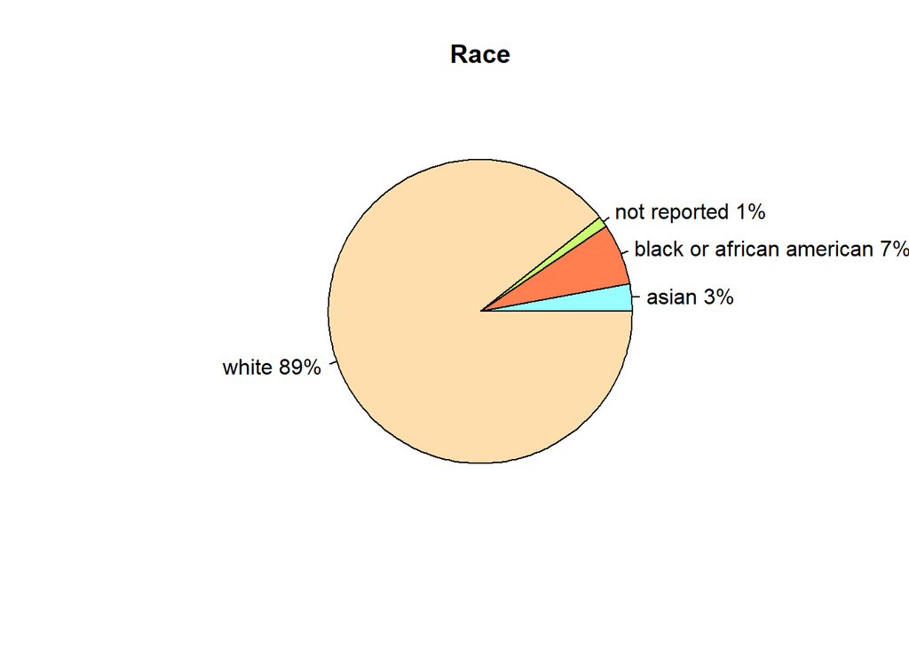

```r
table=table(race1)
data=as.data.frame(table)
slices=data$Freq
lbls=data$race1
pct=round(slices/sum(slices)*100)
lbls=paste(lbls, pct)
lbls=paste(lbls,"%",sep="")
pie(slices,labels = lbls, col = c("darkslategray1", "coral", "darkolivegreen1", "navajowhite"),
    main="Race")
```

## 6.2 Análise Exploratória Variáveis –> age_diag

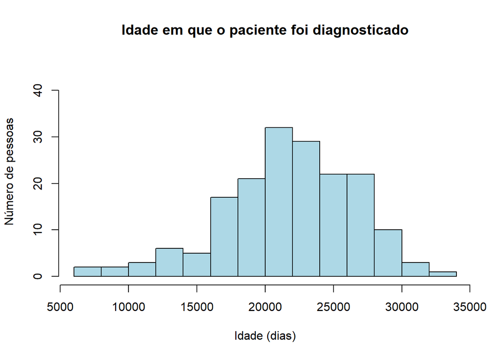

```r
hist(age_diag, col = c("lightblue"), main= "Idade em que o paciente foi diagnosticado", xlab = "Idade (dias)", ylab = "Número de pessoas", ylim = c(0,45))
```

## 6.3 Análise Exploratória Variáveis –> death

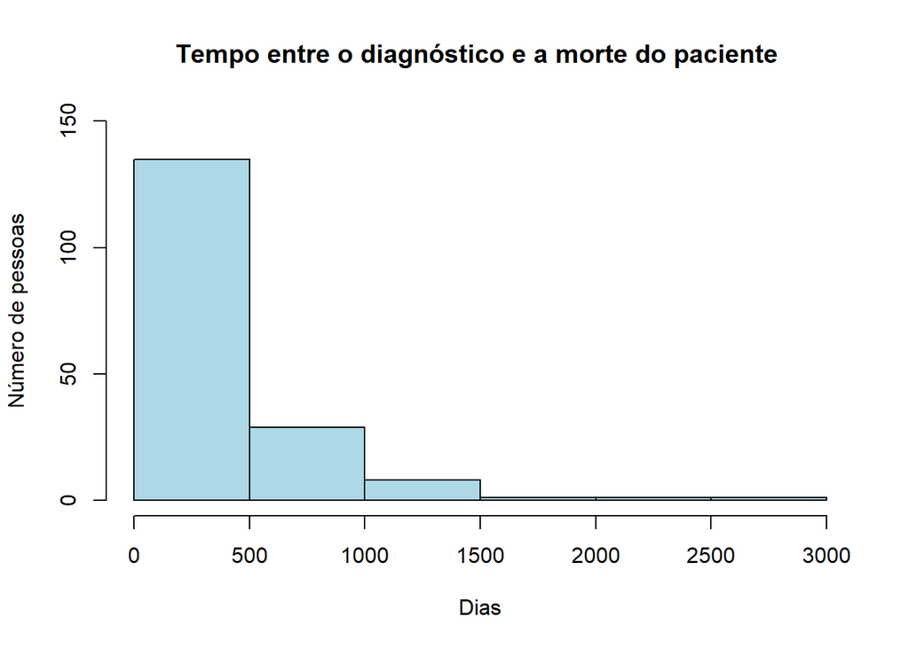

```r
hist(death, col = c("lightblue"), main= "Tempo entre o diagnóstico e a morte do paciente ", xlab = "Dias", ylab = "Número de pessoas", ylim=c(0,150))
```

## 6.4 Análise Exploratória Variáveis –> gender

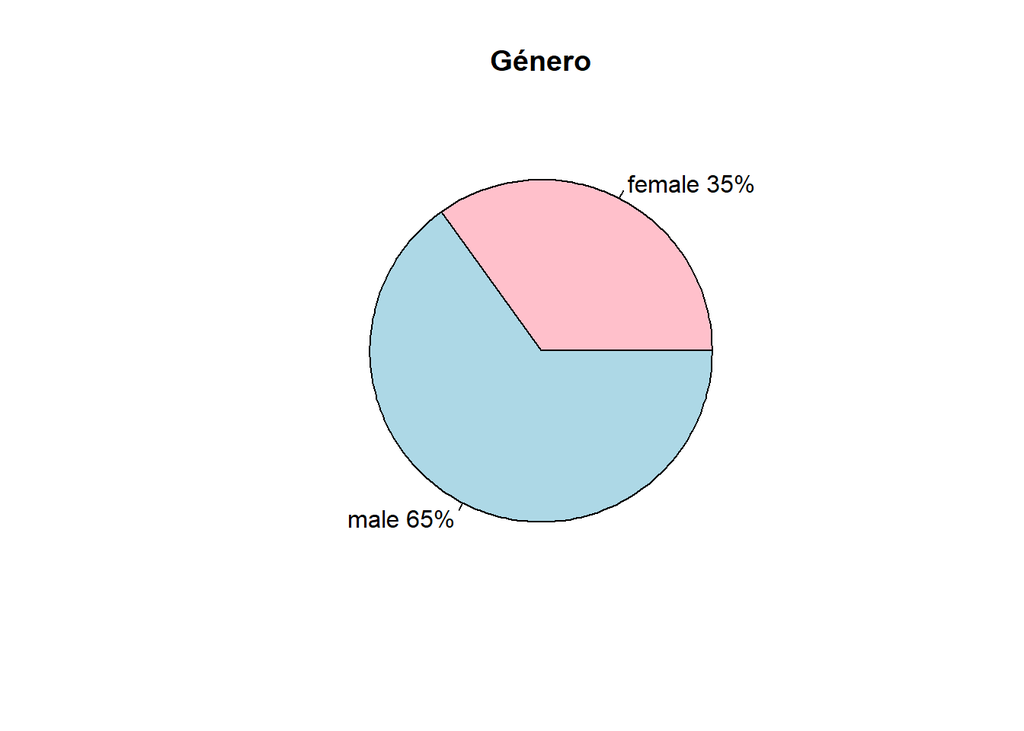

```r
table=table(gender1)
data=as.data.frame(table)
slices=data$Freq
lbls=data$gender1
pct=round(slices/sum(slices)*100)
lbls=paste(lbls, pct)
lbls=paste(lbls,"%",sep="")
pie(slices,labels = lbls, col = c("pink", "lightblue"), main="Género")
```

## 6.5 Análise Exploratória Variáveis –> p_IDH

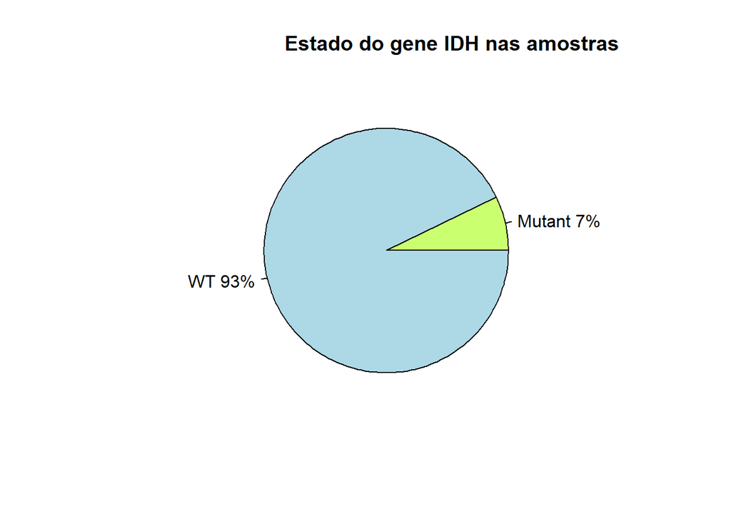

```r
table=table(p_IDH1)
data=as.data.frame(table)
slices=data$Freq
lbls=data$p_IDH1
pct=round(slices/sum(slices)*100)
lbls=paste(lbls, pct)
lbls=paste(lbls,"%",sep="")
pie(slices,labels = lbls, col = c("darkolivegreen1","lightblue"), main="                      Estado do gene IDH nas amostras")
```

## 6.6 Análise Exploratória Variáveis –> patient

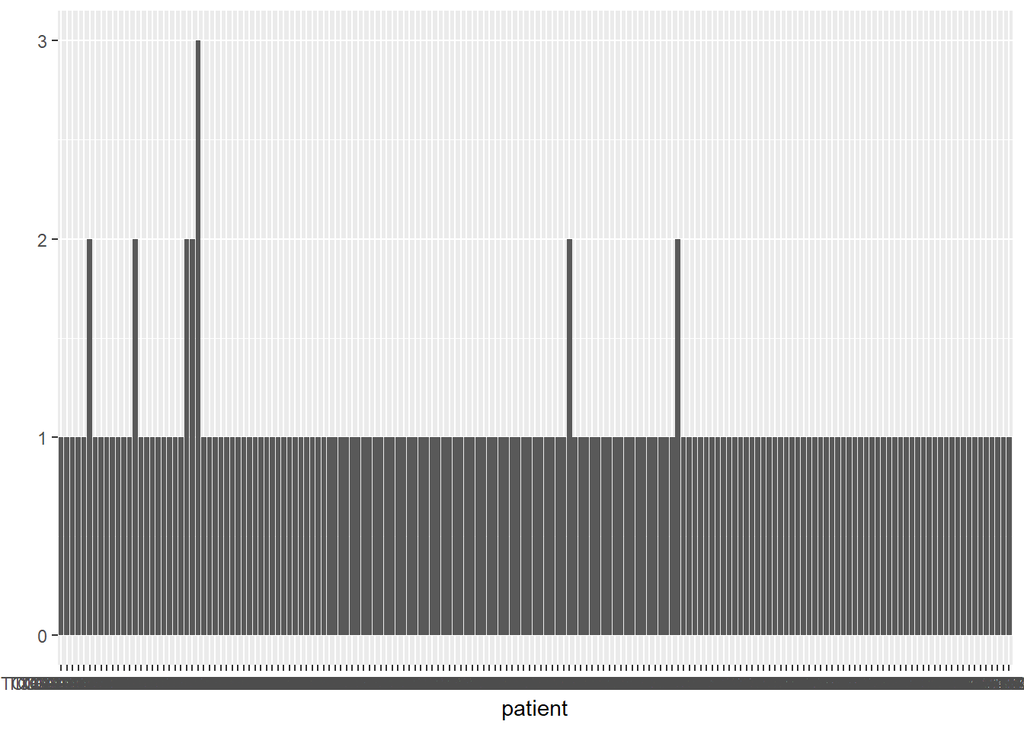

```r
qplot(patient)
```

Problema: Existem casos em que varios pacientes tem o mesmo ID.

## 6.7 Análise Exploratória Variáveis –> tissue

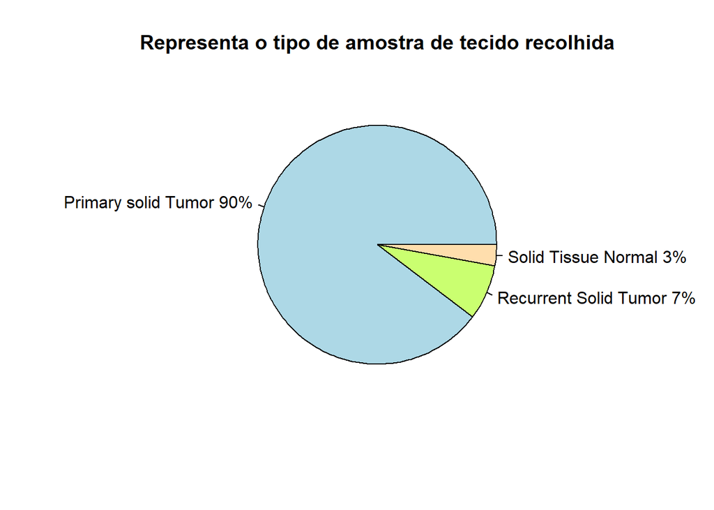

```r
table=table(tissue)
data=as.data.frame(table)
slices=data$Freq
lbls=data$tissue
pct=round(slices/sum(slices)*100)
lbls=paste(lbls, pct)
lbls=paste(lbls,"%",sep="")
pie(slices,labels = lbls, col = c("lightblue","darkolivegreen1", "navajowhite"), main="Representa o tipo de amostra de tecido recolhida")
```

## 6.8 Análise Exploratória Variáveis –> mutation

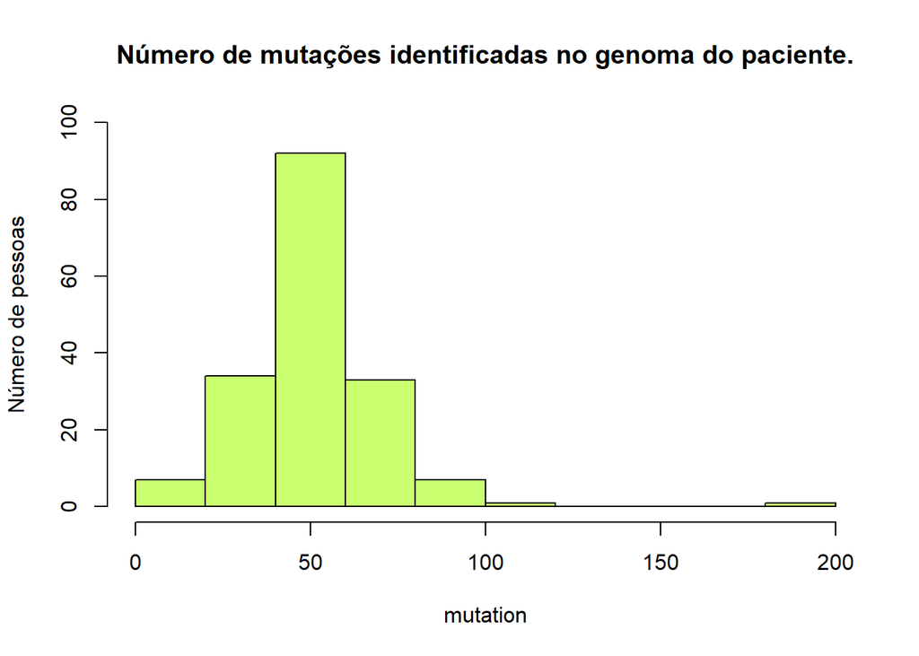

```r
hist(mutation, col = "darkolivegreen1", main = "Número de mutações identificadas no genoma do paciente.",ylab = "Número de pessoas", ylim = c(0,100))
```

## 6.9 Análise Exploratória Variáveis –> vital_st

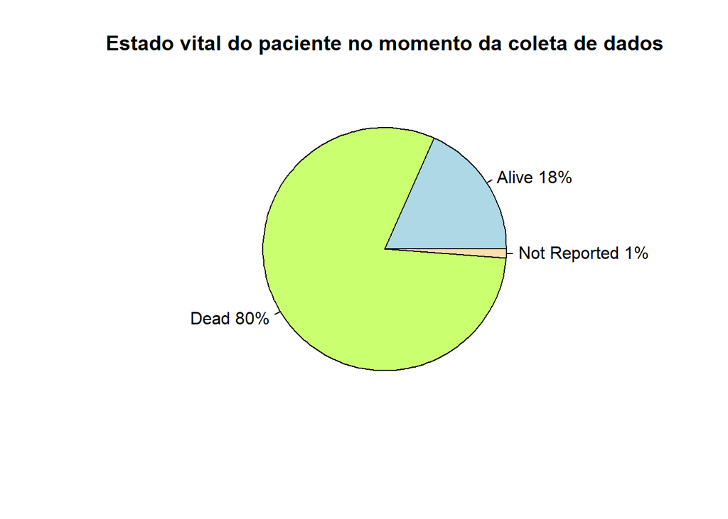

```r
table=table(vital_st1)
data=as.data.frame(table)
slices=data$Freq
lbls=data$vital_st1
pct=round(slices/sum(slices)*100)
lbls=paste(lbls, pct)
lbls=paste(lbls,"%",sep="")
pie(slices,labels = lbls, col = c("lightblue","darkolivegreen1", "navajowhite"), main="Estado vital do paciente no momento da coleta de dados")
```

## 6.10 Análise Exploratória Variáveis –> subtype

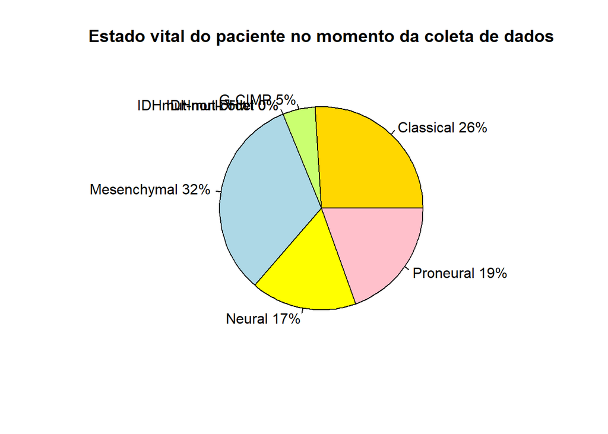

```r
table=table(subtype1)
data=as.data.frame(table)
slices=data$Freq
lbls=data$subtype1
pct=round(slices/sum(slices)*100)
lbls=paste(lbls, pct)
lbls=paste(lbls,"%",sep="")
pie(slices,labels = lbls, col = c("gold","darkolivegreen1","navajowhite","coral","purple", "lightblue","yellow", "pink"), main="Estado vital do paciente no momento da coleta de dados") #tirar as que nao tem
```

## Análise Estatística

### 6.10.1 Avaliar a relação entre o género e a idade de diagnótico

De forma a ser possível fazer a análise estatística inerente, é necessário primeiro verificar a normalidade dos dados. Para tal recorremos ao teste de Shapiro-Wilk.

**H0 (Hipótese nula):** Dados seguem uma distribuição normal.

**H1 (Hipótese alternativa):** Dados não seguem uma distribuição normal.

```r
shapiro.test(age_diag)
```

```
##
##  Shapiro-Wilk normality test
##
## data:  age_diag
## W = 0.98009, p-value = 0.01309
```

**Conclusão:** Uma vez que o p-value resultante deste teste é uma valor inferior a 0,05, rejeitamos a hipótese nula e concluímos que esta variável não apresenta uma distribuição normal.

Desta forma, utilizamos o teste Mann-Whitney como uma alternativa não paramétrica para duas amostras independentes.

**H0:** Não há diferenças significativas na idade de diagnóstico devido ao sexo.

**H1:** Há diferenças significativas na idade de diagnóstico devido ao sexo.

```r
wilcox.test(age_diag~gender)
```

```
##
##  Wilcoxon rank sum test with continuity correction
##
## data:  age_diag by gender
## W = 3713.5, p-value = 0.1227
## alternative hypothesis: true location shift is not equal to 0
```

**Conclusão:** Como a estatistica é de 3713.5 e o valor-p é maior que 0.05 (p-value = 0.1227), a hipótese nula não é rejeitada portanto, podemos concluir que não existem diferenças nas idades de diagnóstico do cancro entre sexos.

**Análise Gráfica: Boxplot Idade aquando do diagnóstico vs Género**

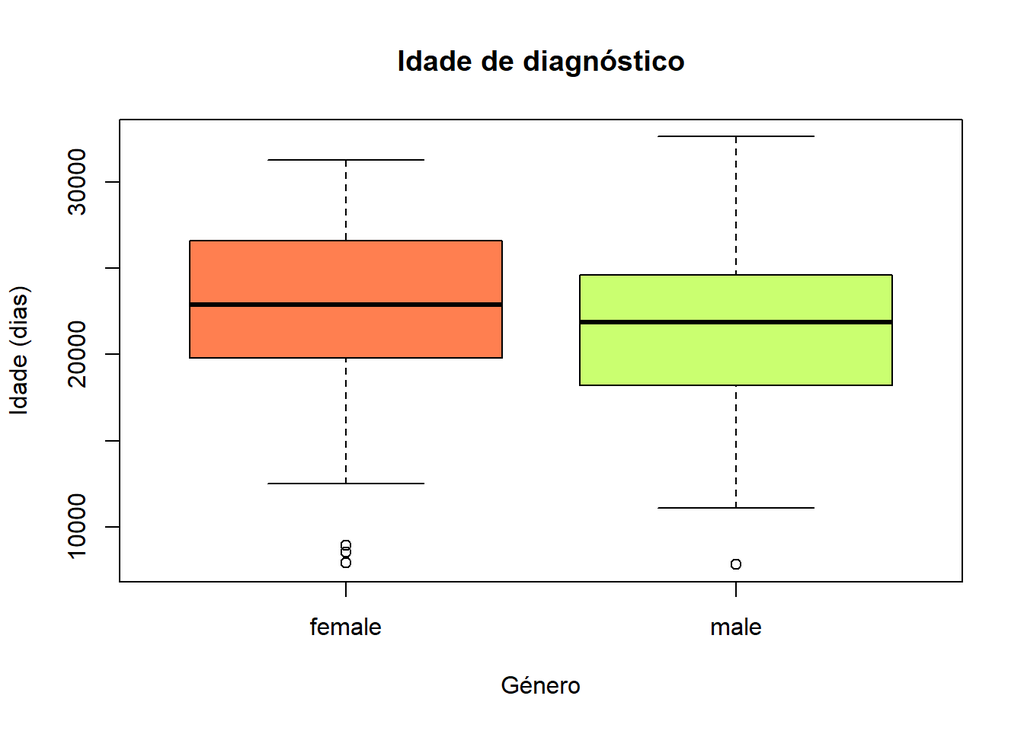

```r
boxplot(age_diag ~ gender, main = "Idade de diagnóstico", xlab = "Género", ylab = "Idade (dias)", col = c( "coral", "darkolivegreen1"))
```

Este gráfico confirma visualmente o evidenciado anteriormente, mostrando que não existem diferenças significativas na idade de diagnóstico entre sexos opostos.

### 6.10.2 Avaliar a relação entre o subtipo de cancro e número de mutações

**H0:** Dados seguem uma distribuição normal.

**H1:** Dados não seguem uma distribuição normal.

```r
shapiro.test(mutation)
```

```
##
##  Shapiro-Wilk normality test
##
## data:  mutation
## W = 0.87014, p-value = 3.797e-11
```

**Conclusão:** Uma vez que o p-value resultante deste teste é uma valor inferior a 0,05, rejeitamos a hipótese nula e concluimos que esta variável não apresenta uma distribuição normal.

Uma vez rejeitada a normalidade dos dados, recorremos a um teste não paramétrico. Visto que a variável categórica subtype apresenta mais que dois subníveis utilizamos o teste kruskal-wallis.

**H0:** Não há diferenças significativas no número de mutações devido aos diferentes subtipos de cancro.

**H1:** (Hipótese alternativa): Há diferenças significativas no número de mutações devido aos diferentes subtipos de cancro.

```r
kruskal.test(mutation~subtype)
```

```
##
##  Kruskal-Wallis rank sum test
##
## data:  mutation by subtype
## Kruskal-Wallis chi-squared = 7.0103, df = 4, p-value = 0.1353
```

**Conclusão:** Uma vez que o p-value é maior que 0,05, não se rejeita a hipótese nula, e concluimos que não existem diferenças no número de mutações entre os diferentes subtipos de cancro.

**Análise Gráfica: Boxplot de número de mutações com os diferentes subtipos de cancro**

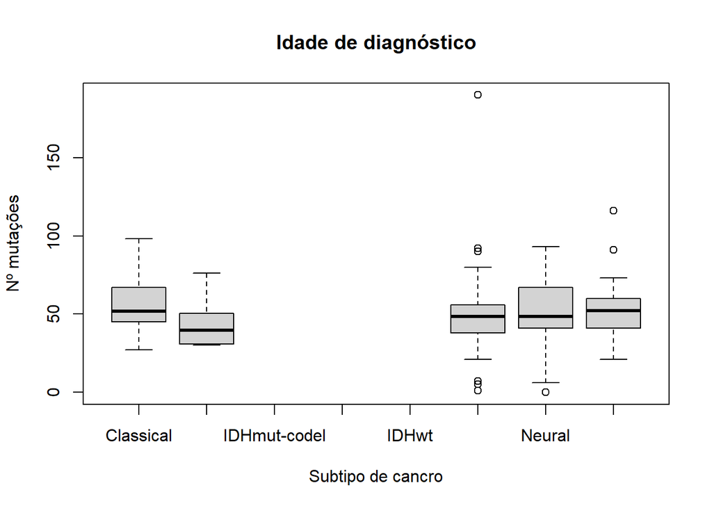

```r
boxplot(mutation ~ subtype, main = "Idade de diagnóstico", xlab = "Subtipo de cancro", ylab = "Nº mutações", at = 1:8)
```

Este gráfico confirma visualmente o evidenciado anteriormente, mostrando que não existem diferenças significativas no número de mutações devido aos diferentes subtipos de cancro.

**Teste Qui-Quadrado**

**H0:** As variáveis são independentes.

**H1:** As variáveis não são independentes.

```r
g_v = table(gender,vital_st)
g_v
```

```
##         vital_st
## gender   Alive Dead Not Reported
##   female    12   47            0
##   male      19   89            2
```

```r
chisq.test(g_v)
```

```
##
##  Pearson's Chi-squared test
##
## data:  g_v
## X-squared = 1.277, df = 2, p-value = 0.5281
```

# 7 Análise da Expressão diferencial

A análise de expressão diferencial vai ser realizada usando o pacote DESeq2 do Bioconductor.

## 7.1 Análise da Espressão Diferencial do IDH.status

```r
data_de = gbm[,!is.na(gbm$paper_IDH.status)]

ddsSE_IDH = DESeqDataSet(data_de, design = ~ paper_IDH.status)
```

```
## renaming the first element in assays to 'counts'
```

```r
keep = rowSums(counts(ddsSE_IDH)) >= 10  #Objetivo do filtro: filtrar as linhas da matriz (counts) que possuem baixos niveis de expressão em todas as amostras.


ddsSE_IDH = ddsSE_IDH[keep,]
ddsSE_IDH = DESeq(ddsSE_IDH)
```

```
## -- replacing outliers and refitting for 2134 genes
## -- DESeq argument 'minReplicatesForReplace' = 7
## -- original counts are preserved in counts(dds)
```

```r
resultsNames(ddsSE_IDH)
```

```
## [1] "Intercept"                     "paper_IDH.status_WT_vs_Mutant"
```

```r
res_IDH = results(ddsSE_IDH, name = "paper_IDH.status_WT_vs_Mutant")

summary(res_IDH)
```

```
##
## out of 47965 with nonzero total read count
## adjusted p-value < 0.1
## LFC > 0 (up)       : 3464, 7.2%
## LFC < 0 (down)     : 2821, 5.9%
## outliers [1]       : 0, 0%
## low counts [2]     : 13020, 27%
## (mean count < 1)
## [1] see 'cooksCutoff' argument of ?results
## [2] see 'independentFiltering' argument of ?results
```

```r
res_IDH
```

```
## log2 fold change (MLE): paper IDH.status WT vs Mutant
## Wald test p-value: paper IDH.status WT vs Mutant
## DataFrame with 47966 rows and 6 columns
##                       baseMean log2FoldChange     lfcSE      stat      pvalue
##                      <numeric>      <numeric> <numeric> <numeric>   <numeric>
## ENSG00000000003.15   4224.2534      0.3269225 0.2135458  1.530924 0.125788082
## ENSG00000000005.6      17.3692      1.2925290 0.5302784  2.437454 0.014791106
## ENSG00000000419.13   1246.0457      0.0430549 0.1401679  0.307167 0.758716336
## ENSG00000000457.14    452.5884     -0.3168180 0.0934881 -3.388859 0.000701842
## ENSG00000000460.17    337.8146     -0.2997261 0.1561127 -1.919934 0.054866202
## ...                        ...            ...       ...       ...         ...
## ENSG00000288667.1    0.1632978      0.3698912  2.265546  0.163268 0.870307397
## ENSG00000288669.1    0.0988085     -0.9658065  2.218209 -0.435399 0.663272603
## ENSG00000288670.1  212.9717472     -0.5109634  0.148944 -3.430579 0.000602294
## ENSG00000288674.1    4.6153236     -0.0600142  0.331727 -0.180914 0.856434845
## ENSG00000288675.1   47.7256360      0.3726411  0.196557  1.895844 0.057980724
##                          padj
##                     <numeric>
## ENSG00000000003.15 0.34165944
## ENSG00000000005.6  0.08775721
## ENSG00000000419.13 0.88839340
## ENSG00000000457.14 0.00973663
## ENSG00000000460.17 0.20748863
## ...                       ...
## ENSG00000288667.1          NA
## ENSG00000288669.1          NA
## ENSG00000288670.1  0.00867166
## ENSG00000288674.1  0.93733079
## ENSG00000288675.1  0.21477574
```

O resumo (summary(res)) mostra que dos 47.965 genes analisados, 3.464 (7,2%) foram up-regulated(Log2 fold change > 0) nas amostras de tipo WT de IDH em comparação com aquelas de mutante de IDH. Por outro lado, 2.821 (5,9%) genes foram down-regulated (Log2 fold change < 0) na mesma comparação.

Também podemos analisar que não houve outliers detetados nos dados e 13.020 genes (27%) tiveram contagens baixas (contagem média < 1), que não foram usados na análise. Finalmente, o #ponto de corte# do valor de prova ajustado usado para determinar a significância foi menor que 0,1. Exploração Gráfica: De seguida vamos analisar o gráfico MA, para visualizar as diferenças de expressão génica entre dois grupos.

Portanto, se considerarmos aceitável uma fração de 10% de falsos positivos, podemos considerar todos os genes com valor de p ajustado abaixo de 10% = 0,1 como significativos.

Existem 6285 genes significativos.

```r
sum(res_IDH$padj < 0.1, na.rm=TRUE)
```

```
## [1] 6285
```

Portanto, se considerarmos aceitável uma fração de 5% de falsos positivos, podemos considerar todos os genes com valor de p ajustado abaixo de 5% como significativos.

Existem 4641 genes significativos.

```r
sum(res_IDH$padj < 0.05, na.rm=TRUE)
```

```
## [1] 4641
```

Subdefinimos a tabela de resultados para esses genes e, em seguida, classificamos pela estimativa de fold-change de log2 para obter os genes significativos com a regulação negativa mais forte:

```r
resSig <- subset(res_IDH, padj < 0.1)
head(resSig[ order(resSig$log2FoldChange), ])
```

```
## log2 fold change (MLE): paper IDH.status WT vs Mutant
## Wald test p-value: paper IDH.status WT vs Mutant
## DataFrame with 6 rows and 6 columns
##                      baseMean log2FoldChange     lfcSE      stat      pvalue
##                     <numeric>      <numeric> <numeric> <numeric>   <numeric>
## ENSG00000237164.1    1.577333       -5.57848  1.261413  -4.42241 9.76065e-06
## ENSG00000189295.13   1.081086       -5.51582  1.051675  -5.24480 1.56454e-07
## ENSG00000100181.22 245.962603       -5.27367  0.489363 -10.77660 4.44003e-27
## ENSG00000268079.1    1.652377       -4.96637  0.823864  -6.02814 1.65862e-09
## ENSG00000253953.3   52.296061       -4.87689  0.398251 -12.24578 1.76971e-34
## ENSG00000286008.1    0.855301       -4.79759  1.195233  -4.01394 5.97141e-05
##                           padj
##                      <numeric>
## ENSG00000237164.1  3.51645e-04
## ENSG00000189295.13 1.19116e-05
## ENSG00000100181.22 3.10323e-23
## ENSG00000268079.1  2.78664e-07
## ENSG00000253953.3  3.09221e-30
## ENSG00000286008.1  1.49055e-03
```

…e com a regulação positiva mais forte:

```r
head(resSig[ order(resSig$log2FoldChange, decreasing = TRUE), ])
```

```
## log2 fold change (MLE): paper IDH.status WT vs Mutant
## Wald test p-value: paper IDH.status WT vs Mutant
## DataFrame with 6 rows and 6 columns
##                    baseMean log2FoldChange     lfcSE      stat      pvalue
##                   <numeric>      <numeric> <numeric> <numeric>   <numeric>
## ENSG00000204542.3  185.8850        5.75478  0.852409   6.75120 1.46630e-11
## ENSG00000229108.2  527.5689        5.44811  0.516410  10.54997 5.08119e-26
## ENSG00000106511.6 1632.5452        5.28235  0.454732  11.61639 3.40208e-31
## ENSG00000120068.7   75.9438        4.94438  0.829679   5.95940 2.53172e-09
## ENSG00000286802.1   23.6646        4.78875  0.787522   6.08079 1.19595e-09
## ENSG00000144820.8   30.6914        4.70220  0.795059   5.91428 3.33331e-09
##                          padj
##                     <numeric>
## ENSG00000204542.3 5.12415e-09
## ENSG00000229108.2 2.95946e-22
## ENSG00000106511.6 3.96297e-27
## ENSG00000120068.7 4.03989e-07
## ENSG00000286802.1 2.10018e-07
## ENSG00000144820.8 5.02095e-07
```

**TopGene**

E podemos observar também o TopGene que corresponde ao gene com menor valor de padj.

```r
topGene = rownames(res_IDH)[which.min(res_IDH$padj)]
topGene
```

```
## [1] "ENSG00000205323.9"
```

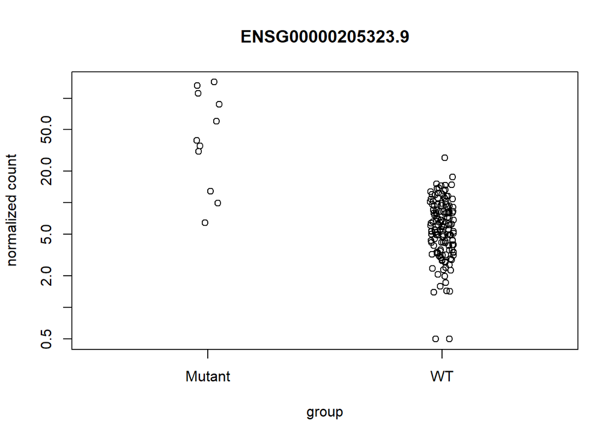

```r
plotCounts(ddsSE_IDH, gene = topGene, intgroup=c("paper_IDH.status"))
```

**Exploração gráfica: MA Plot**

Este vai nos permitir para visualizar as diferenças de expressão génica entre dois grupos: Genes Diferencialmente Expressos(azul), Outros Genes (Cinza). E podemos observar também o TopGene que corresponde ao gene com menor valor de padj

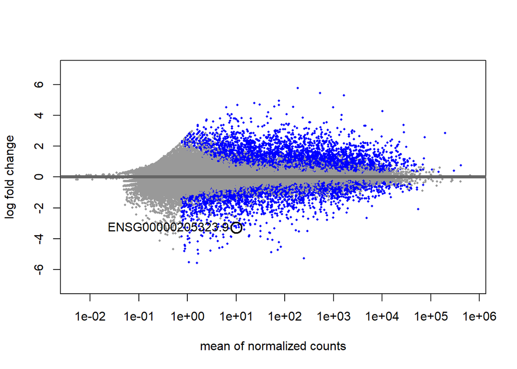

```r
DESeq2::plotMA(res_IDH, ylim = c(-7,7))

with(res_IDH[topGene, ], {
  DESeq2::plotMA(res_IDH, ylim = c(-7,7))
  points(baseMean, log2FoldChange, col="black", cex=2, lwd=2)
  text(baseMean, log2FoldChange, topGene, pos=2, col="black")
})
```

Um gráfico de diagnóstico que também é útil é o histograma dos valores de p (figura abaixo). Este gráfico é melhor formado excluindo genes com contagens muito pequenas, que de outra forma geram picos no histograma.

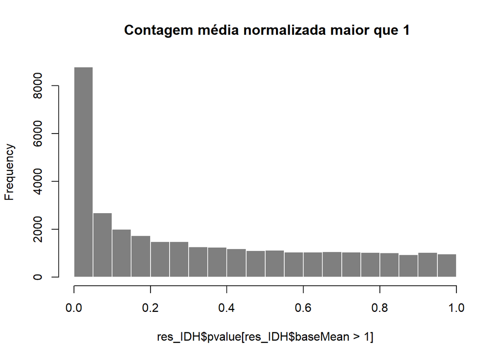

```r
hist(res_IDH$pvalue[res_IDH$baseMean > 1], breaks = 0:20/20,
     col = "grey50", border = "white", main=' Contagem média normalizada maior que 1')
```

## 7.2 Análise da Expressão Diferencial do Género

```r
data_de = gbm[,!is.na(gbm$paper_Gender)]

ddsSE_sex = DESeqDataSet(data_de, design = ~ paper_Gender)
```

```
## renaming the first element in assays to 'counts'
```

```r
keep = rowSums(counts(ddsSE_sex)) >= 10
ddsSE_sex = ddsSE_sex[keep,]
ddsSE_sex = DESeq(ddsSE_sex)
```

```
## -- replacing outliers and refitting for 2975 genes
## -- DESeq argument 'minReplicatesForReplace' = 7
## -- original counts are preserved in counts(dds)
```

```r
resultsNames(ddsSE_sex)
```

```
## [1] "Intercept"                   "paper_Gender_male_vs_female"
```

```r
res_sex = results(ddsSE_sex, name = "paper_Gender_male_vs_female")

summary(res_sex)
```

```
##
## out of 48091 with nonzero total read count
## adjusted p-value < 0.1
## LFC > 0 (up)       : 210, 0.44%
## LFC < 0 (down)     : 115, 0.24%
## outliers [1]       : 0, 0%
## low counts [2]     : 13057, 27%
## (mean count < 1)
## [1] see 'cooksCutoff' argument of ?results
## [2] see 'independentFiltering' argument of ?results
```

Portanto, se considerarmos aceitável uma fração de 10% de falsos positivos, podemos considerar todos os genes com valor de p ajustado abaixo de 10% = 0,1 como significativos.

Existem 325 genes diferencialmente expressos:

```r
sum(res_sex$padj < 0.1, na.rm=TRUE)
```

```
## [1] 325
```

Portanto, se considerarmos aceitável uma fração de 5% de falsos positivos, podemos considerar todos os genes com valor de p ajustado abaixo de 5% como significativos.

Existindo, neste caso, 226 genes significativamente expressos:

```r
sum(res_sex$padj < 0.05, na.rm=TRUE)
```

```
## [1] 226
```

Subdefinimos a tabela de resultados para esses genes e, em seguida, classificamos pela estimativa de fold change log2 para obter os genes significativos com a regulação negativa mais forte:

```r
resSig <- subset(res_sex, padj < 0.1)
head(resSig[ order(resSig$log2FoldChange), ])
```

```
## log2 fold change (MLE): paper Gender male vs female
## Wald test p-value: paper Gender male vs female
## DataFrame with 6 rows and 6 columns
##                     baseMean log2FoldChange     lfcSE      stat       pvalue
##                    <numeric>      <numeric> <numeric> <numeric>    <numeric>
## ENSG00000229807.12 577.29740       -6.51344  0.185463 -35.11992 3.34777e-270
## ENSG00000112175.8  118.60413       -3.12503  0.430612  -7.25719  3.95225e-13
## ENSG00000126890.13   1.17455       -2.78493  0.685210  -4.06434  4.81690e-05
## ENSG00000162624.14   5.96271       -2.57104  0.691475  -3.71820  2.00650e-04
## ENSG00000166509.12   4.55893       -2.10306  0.453733  -4.63502  3.56896e-06
## ENSG00000231431.7    2.04337       -2.00162  0.439675  -4.55250  5.30119e-06
##                            padj
##                       <numeric>
## ENSG00000229807.12 1.17299e-266
## ENSG00000112175.8   3.14725e-10
## ENSG00000126890.13  1.16396e-02
## ENSG00000162624.14  3.70020e-02
## ENSG00000166509.12  1.38944e-03
## ENSG00000231431.7   1.95519e-03
```

…e com a regulação positiva mais forte:

```r
head(resSig[ order(resSig$log2FoldChange, decreasing = TRUE), ])
```

```
## log2 fold change (MLE): paper Gender male vs female
## Wald test p-value: paper Gender male vs female
## DataFrame with 6 rows and 6 columns
##                     baseMean log2FoldChange     lfcSE      stat       pvalue
##                    <numeric>      <numeric> <numeric> <numeric>    <numeric>
## ENSG00000183878.15  414.0132        6.55383  0.119613   54.7918  0.00000e+00
## ENSG00000154620.6    43.7835        6.41826  0.244993   26.1977 2.82148e-151
## ENSG00000176728.10  136.7811        6.34493  0.182902   34.6904 1.09933e-263
## ENSG00000067646.12  359.8870        6.31103  0.114833   54.9583  0.00000e+00
## ENSG00000012817.16 1026.7272        6.28264  0.139253   45.1166  0.00000e+00
## ENSG00000198692.10  643.6066        6.24272  0.134948   46.2603  0.00000e+00
##                            padj
##                       <numeric>
## ENSG00000183878.15  0.00000e+00
## ENSG00000154620.6  7.60454e-148
## ENSG00000176728.10 3.50167e-260
## ENSG00000067646.12  0.00000e+00
## ENSG00000012817.16  0.00000e+00
## ENSG00000198692.10  0.00000e+00
```

Vamos ver o plot do gene que apresentou o menor valor de prova ajustado (padj), na comparação entre os grupos “male” e “female” do metadado “paper_Gender”.

```r
topGene = rownames(res_sex)[which.min(res_sex$padj)]
topGene
```

```
## [1] "ENSG00000012817.16"
```

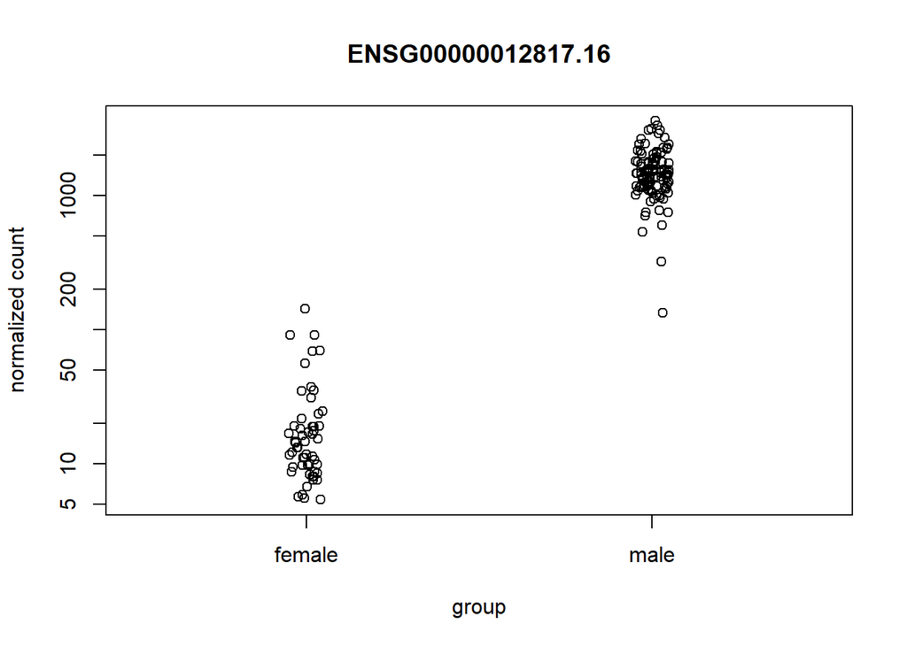

```r
plotCounts(ddsSE_sex, gene = topGene, intgroup=c("paper_Gender"))
```

**Exploração gráfica: MA Plot**

Exploração Gráfica: De seguida vamos analisar o gráfico MA, para visualizar as diferenças de expressão génica entre dois grupos. Genes Diferencialmente Expressos(azul), Outros Genes (Cinza) e adicionámos também o TopGene ao Gráfico.

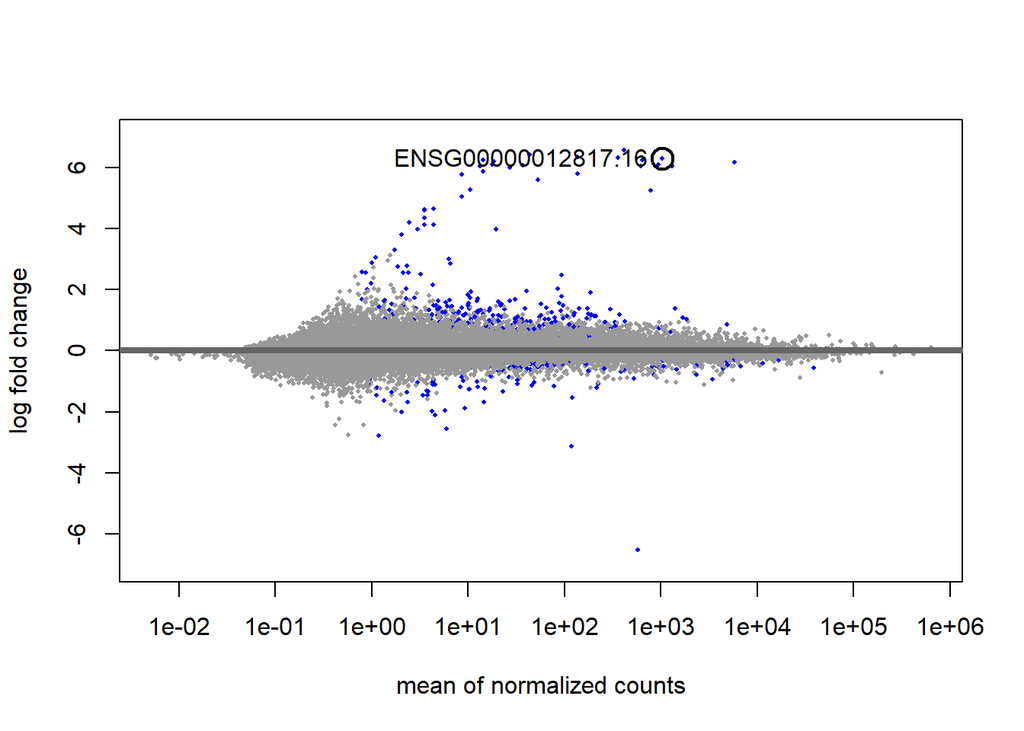

```r
DESeq2::plotMA(res_sex, ylim = c(-7,7))

with(res_sex[topGene, ], {
  points(baseMean, log2FoldChange, col="black", cex=2, lwd=2)
  text(baseMean, log2FoldChange, topGene, pos=2, col="black")
})
```

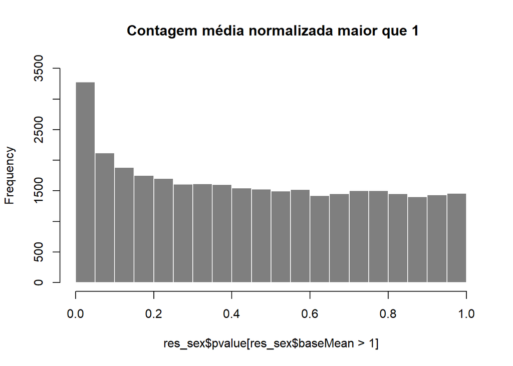

```r
hist(res_sex$pvalue[res_sex$baseMean > 1], breaks = 0:20/20,
     col = "grey50", border = "white", main=' Contagem média normalizada maior que 1', ylim=c(0,3500))
```

## 7.3 Análise da Expressão Diferencial do Subtype

```r
data_de = gbm[,!is.na(gbm$paper_Original.Subtype)]

ddsSE_subtype = DESeqDataSet(data_de, design = ~ paper_Original.Subtype)
```

```
## renaming the first element in assays to 'counts'
```

```
## factor levels were dropped which had no samples
```

[output not shown]

```r
keep = rowSums(counts(ddsSE_subtype)) >= 10
ddsSE_subtype = ddsSE_subtype[keep,]
ddsSE_subtype = DESeq(ddsSE_subtype)
```

[output not shown]

[output not shown]

[output not shown]

[output not shown]

```
## -- replacing outliers and refitting for 1473 genes
## -- DESeq argument 'minReplicatesForReplace' = 7
## -- original counts are preserved in counts(dds)
```

[output not shown]

[output not shown]

```r
resultsNames(ddsSE_subtype)
```

```
## [1] "Intercept"
## [2] "paper_Original.Subtype_G.CIMP_vs_Classical"
## [3] "paper_Original.Subtype_Mesenchymal_vs_Classical"
## [4] "paper_Original.Subtype_Neural_vs_Classical"
## [5] "paper_Original.Subtype_Proneural_vs_Classical"
```

```r
res = results(ddsSE_subtype, name = "paper_Original.Subtype_Mesenchymal_vs_Classical")

summary(res)
```

```
##
## out of 48040 with nonzero total read count
## adjusted p-value < 0.1
## LFC > 0 (up)       : 8305, 17%
## LFC < 0 (down)     : 5485, 11%
## outliers [1]       : 0, 0%
## low counts [2]     : 9316, 19%
## (mean count < 0)
## [1] see 'cooksCutoff' argument of ?results
## [2] see 'independentFiltering' argument of ?results
```

O resumo (summary(res)) mostra que dos 48040 genes analisados, 8305 (17%) foram up-regulated(Log2 fold change > 0). Por outro lado, 5485 (11%) genes foram down-regulated (Log2 fold change < 0) na mesma comparação.

Portanto, se considerarmos aceitável uma fração de 10% de falsos positivos, podemos considerar todos os genes com valor de p ajustado abaixo de 10% = 0,1 como significativos.

Existem 13790 genes diferencialmente expressos.

```r
sum(res$padj < 0.1, na.rm=TRUE)
```

```
## [1] 13790
```

```r
sum(res$padj < 11157, na.rm=TRUE)
```

```
## [1] 38726
```

Subdefinimos a tabela de resultados para esses genes e, em seguida, classificamos pela estimativa de fold change log2 para obter os genes significativos com a regulação negativa mais forte:

```r
resSig <- subset(res, padj < 0.1)
head(resSig[ order(resSig$log2FoldChange), ])
```

```
## log2 fold change (MLE): paper Original.Subtype Mesenchymal vs Classical
## Wald test p-value: paper Original.Subtype Mesenchymal vs Classical
## DataFrame with 6 rows and 6 columns
##                    baseMean log2FoldChange     lfcSE      stat      pvalue
##                   <numeric>      <numeric> <numeric> <numeric>   <numeric>
## ENSG00000261275.1   2.36067       -3.70634  0.771527  -4.80391 1.55599e-06
## ENSG00000149656.8  11.90887       -3.62121  0.517336  -6.99973 2.56452e-12
## ENSG00000249948.6  16.36706       -3.50778  0.518321  -6.76758 1.30951e-11
## ENSG00000234707.3 130.90644       -3.18226  0.385262  -8.25998 1.45697e-16
## ENSG00000228735.1   2.39900       -3.17859  0.692929  -4.58719 4.49260e-06
## ENSG00000217929.4   4.89981       -3.08377  0.529125  -5.82805 5.60796e-09
##                          padj
##                     <numeric>
## ENSG00000261275.1 2.71918e-05
## ENSG00000149656.8 2.22688e-10
## ENSG00000249948.6 9.65733e-10
## ENSG00000234707.3 4.94474e-14
## ENSG00000228735.1 6.69413e-05
## ENSG00000217929.4 1.96894e-07
```

…e com a regulação positiva mais forte:

```r
head(resSig[ order(resSig$log2FoldChange, decreasing = TRUE), ])
```

```
## log2 fold change (MLE): paper Original.Subtype Mesenchymal vs Classical
## Wald test p-value: paper Original.Subtype Mesenchymal vs Classical
## DataFrame with 6 rows and 6 columns
##                    baseMean log2FoldChange     lfcSE      stat      pvalue
##                   <numeric>      <numeric> <numeric> <numeric>   <numeric>
## ENSG00000282651.2  10.15131        6.36033  0.894992   7.10658 1.18955e-12
## ENSG00000211976.2   7.23380        5.63534  0.753847   7.47544 7.69478e-14
## ENSG00000282639.1   5.64776        5.55401  0.931994   5.95927 2.53363e-09
## ENSG00000276566.1   6.21187        5.19019  0.821234   6.31999 2.61575e-10
## ENSG00000275385.2 212.43654        5.18860  0.457938  11.33036 9.28250e-30
## ENSG00000278196.3  24.77107        5.17918  0.591989   8.74878 2.15663e-18
##                          padj
##                     <numeric>
## ENSG00000282651.2 1.13745e-10
## ENSG00000211976.2 1.06424e-11
## ENSG00000282639.1 9.79214e-08
## ENSG00000276566.1 1.32936e-08
## ENSG00000275385.2 1.79737e-25
## ENSG00000278196.3 1.34706e-15
```

```r
topGene = rownames(res)[which.min(res$padj)]
topGene
```

```
## [1] "ENSG00000124882.4"
```

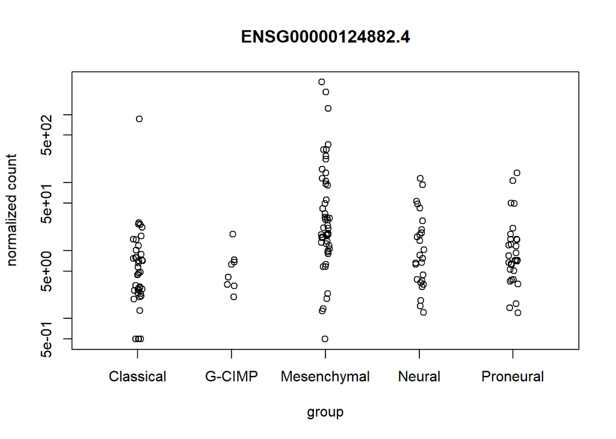

```r
plotCounts(ddsSE_subtype, gene = topGene, intgroup=c("paper_Original.Subtype"))
```

O gene “ENSG00000124882.4” é expresso em todos os subtipos de cancro com maior enfase no Subtype_Mesenchymal.

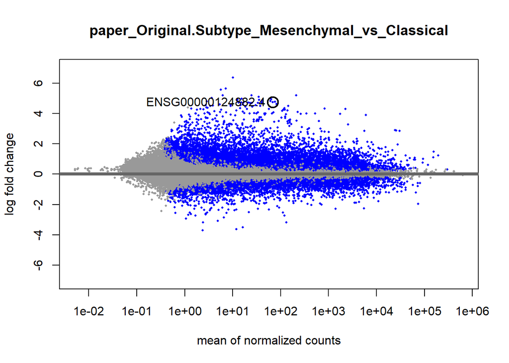

```r
DESeq2::plotMA(res, ylim = c(-7,7), main="paper_Original.Subtype_Mesenchymal_vs_Classical")

with(res[topGene, ], {
  DESeq2::plotMA(res, ylim = c(-7,7), main="paper_Original.Subtype_Mesenchymal_vs_Classical")
  points(baseMean, log2FoldChange, col="black", cex=2, lwd=2)
  text(baseMean, log2FoldChange, topGene, pos=2, col="black")
})
```

Os gráficos de expressão diferencial mostram (azul) os genes que são diferencialmente expressos (DE), entre as diferentes condições que constam da análise anterior.Para além disso, consta também no gráfico o TopGene referente a cada análise.

### 7.3.1 Heatmap gender

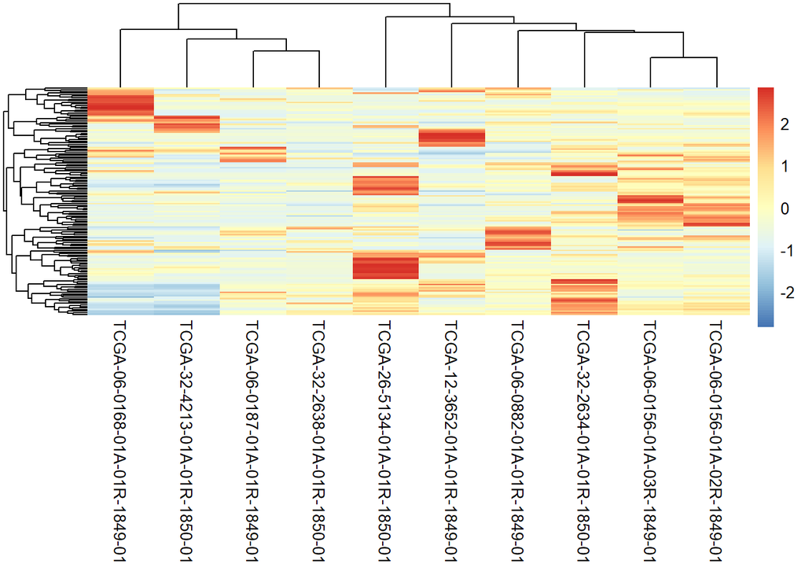

```r
dea = as.data.frame(res_sex)
dea_fc = subset(dea, abs(log2FoldChange) > 1 & padj < 0.05)


norm_counts = counts(ddsSE_sex, normalized=TRUE)[row.names(dea_fc),]
norm_counts = norm_counts[,0:10]



pheatmap(norm_counts, cluster_rows=TRUE, cluster_cols=TRUE, scale="row", show_rownames=FALSE)
```

# 8 Análise de enriquecimento

## 8.1 Análise de enriquecimento do IDH_status

**Sobrexpressão**

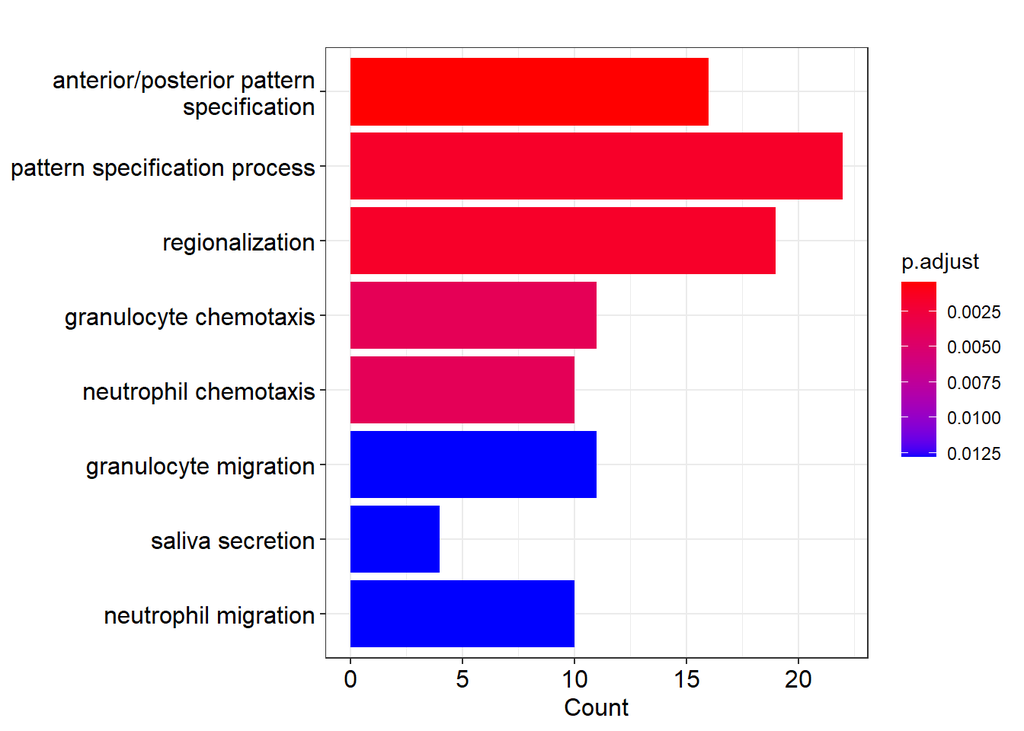

```r
s = na.omit(res_IDH)
s = s[s$padj < 0.05,]
overexp =rownames(s)[s$log2FoldChange>2]
overexp = gsub("\\..*","",overexp)

result = enrichGO(gene = overexp, OrgDb = 'org.Hs.eg.db', keyType = 'ENSEMBL', ont = 'BP')
barplot(result)
```

**Subexpressão**

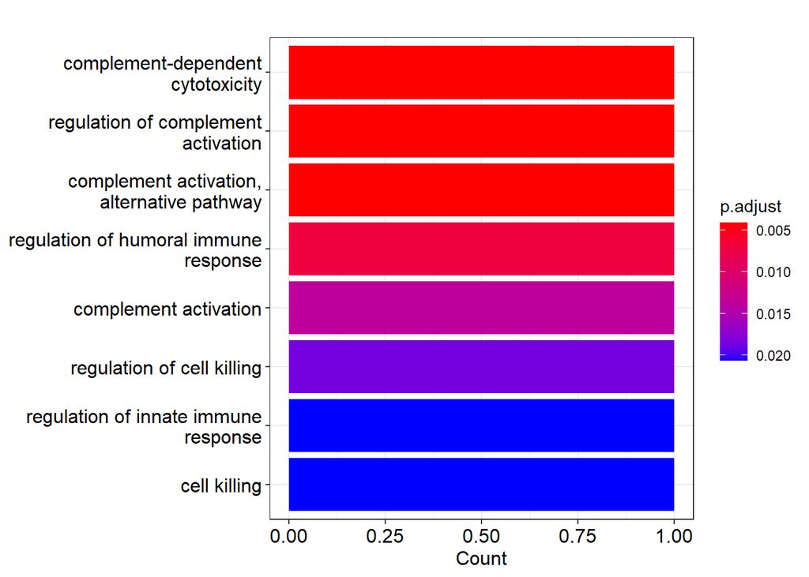

```r
underexp =rownames(s)[s$log2FoldChange<-2]
underexp = gsub("\\..*","",underexp)

result1 = enrichGO(gene = underexp, OrgDb = 'org.Hs.eg.db', keyType = 'ENSEMBL', ont = 'BP')
barplot(result1)
```

Os gráficos anteriormente apresentados, demonstram os termos de gene ontology enriquecidos associados ao nosso dataset cada barra representa um termo go que está associado a uma determinada função biológica. Os valores expressos nos gráficos apresentam apenas os genes com valores de prova menores que 0.05 indicando valores sobreexpressos e subexpressos.

# 9 Redução de dimensionalidade

## 9.1 PCA

O PCA têm como objetivo definir um conjunto mais pequeno de variáveis não correlacionadas entre si que explicam a maior parte da variabilidade dos dados. Este consiste num procedimento algébrico que converte as variáveis originais (tipicamente correlacionadas) num conjunto de variáveis não correlacionadas (linearmente) que se designam por componentes principais (PC) ou variáveis latentes. Cada PC é gerada de forma a explicar o máximo de variabilidade da parte ainda não explicada, tendo que ser ortogonal às PCs anteriores

```r
pca = prcomp(gbm_assay, scale = TRUE)

reduced_data = pca$x
```

```r
summary(pca)
```

```
## Importance of components:
##                            PC1     PC2     PC3     PC4     PC5     PC6     PC7
## Standard deviation     11.4079 3.08731 2.82509 2.28068 1.57461 1.48939 1.40384
## Proportion of Variance  0.7437 0.05447 0.04561 0.02972 0.01417 0.01268 0.01126
## Cumulative Proportion   0.7437 0.79813 0.84373 0.87346 0.88763 0.90030 0.91156
##                            PC8     PC9    PC10    PC11    PC12    PC13    PC14
## Standard deviation     1.17861 1.15696 1.03027 0.86063 0.78735 0.75848 0.74025
## Proportion of Variance 0.00794 0.00765 0.00607 0.00423 0.00354 0.00329 0.00313
## Cumulative Proportion  0.91950 0.92715 0.93322 0.93745 0.94099 0.94428 0.94741
##                           PC15    PC16   PC17    PC18   PC19    PC20    PC21
## Standard deviation     0.69410 0.66615 0.6211 0.60444 0.5766 0.55974 0.54834
## Proportion of Variance 0.00275 0.00254 0.0022 0.00209 0.0019 0.00179 0.00172
## Cumulative Proportion  0.95016 0.95270 0.9549 0.95699 0.9589 0.96068 0.96240
##                          PC22    PC23    PC24    PC25   PC26    PC27    PC28
## Standard deviation     0.5294 0.51383 0.49789 0.46771 0.4581 0.45723 0.43093
## Proportion of Variance 0.0016 0.00151 0.00142 0.00125 0.0012 0.00119 0.00106
## Cumulative Proportion  0.9640 0.96551 0.96692 0.96817 0.9694 0.97057 0.97163
##                          PC29   PC30    PC31    PC32    PC33    PC34    PC35
## Standard deviation     0.4183 0.4176 0.40520 0.39464 0.38796 0.37160 0.36659
## Proportion of Variance 0.0010 0.0010 0.00094 0.00089 0.00086 0.00079 0.00077
## Cumulative Proportion  0.9726 0.9736 0.97456 0.97545 0.97631 0.97710 0.97787
##                           PC36    PC37    PC38    PC39    PC40   PC41    PC42
## Standard deviation     0.35600 0.34873 0.34135 0.33324 0.33143 0.3241 0.31945
## Proportion of Variance 0.00072 0.00069 0.00067 0.00063 0.00063 0.0006 0.00058
## Cumulative Proportion  0.97859 0.97929 0.97996 0.98059 0.98122 0.9818 0.98240
##                           PC43    PC44    PC45    PC46    PC47    PC48    PC49
## Standard deviation     0.31478 0.30908 0.30206 0.29990 0.29172 0.28626 0.27266
## Proportion of Variance 0.00057 0.00055 0.00052 0.00051 0.00049 0.00047 0.00042
## Cumulative Proportion  0.98297 0.98351 0.98403 0.98455 0.98503 0.98550 0.98593
##                           PC50    PC51   PC52    PC53    PC54    PC55    PC56
## Standard deviation     0.27197 0.26912 0.2634 0.25525 0.25435 0.24859 0.24589
## Proportion of Variance 0.00042 0.00041 0.0004 0.00037 0.00037 0.00035 0.00035
## Cumulative Proportion  0.98635 0.98676 0.9872 0.98753 0.98790 0.98826 0.98860
##                           PC57    PC58    PC59    PC60    PC61    PC62    PC63
## Standard deviation     0.24334 0.24180 0.23510 0.23237 0.22622 0.22451 0.22047
## Proportion of Variance 0.00034 0.00033 0.00032 0.00031 0.00029 0.00029 0.00028
## Cumulative Proportion  0.98894 0.98927 0.98959 0.98990 0.99019 0.99048 0.99076
##                           PC64    PC65    PC66    PC67    PC68    PC69    PC70
## Standard deviation     0.21685 0.21441 0.21343 0.20954 0.20724 0.20016 0.19834
## Proportion of Variance 0.00027 0.00026 0.00026 0.00025 0.00025 0.00023 0.00022
```

[output cut: 46 more lines]

```
## Standard deviation     0.06737 0.06668 0.06563 0.06408 0.06349 0.06285 0.06242
## Proportion of Variance 0.00003 0.00003 0.00002 0.00002 0.00002 0.00002 0.00002
## Cumulative Proportion  0.99956 0.99958 0.99961 0.99963 0.99965 0.99968 0.99970
##                          PC155   PC156   PC157   PC158   PC159   PC160   PC161
## Standard deviation     0.06088 0.05952 0.05919 0.05858 0.05752 0.05659 0.05592
## Proportion of Variance 0.00002 0.00002 0.00002 0.00002 0.00002 0.00002 0.00002
## Cumulative Proportion  0.99972 0.99974 0.99976 0.99978 0.99980 0.99982 0.99983
##                          PC162   PC163   PC164   PC165   PC166   PC167   PC168
## Standard deviation     0.05477 0.05438 0.05311 0.04966 0.04916 0.04776 0.04644
## Proportion of Variance 0.00002 0.00002 0.00002 0.00001 0.00001 0.00001 0.00001
## Cumulative Proportion  0.99985 0.99987 0.99988 0.99990 0.99991 0.99993 0.99994
##                          PC169   PC170   PC171   PC172   PC173   PC174   PC175
## Standard deviation     0.04525 0.04469 0.04270 0.03982 0.03786 0.03379 0.02912
## Proportion of Variance 0.00001 0.00001 0.00001 0.00001 0.00001 0.00001 0.00000
## Cumulative Proportion  0.99995 0.99996 0.99997 0.99998 0.99999 1.00000 1.00000
```

```r
i = 1
while ( summary(pca)$importance[3,i] < 0.90 ) i = i + 1
i
```

```
## [1] 6
```

A primeira componente é responsável por explicar a maior parte da variabilidade dos dados, correspondendo a 74%. São necessárias 6 componentes principais para explicar 90% da variabilidade dos dados.

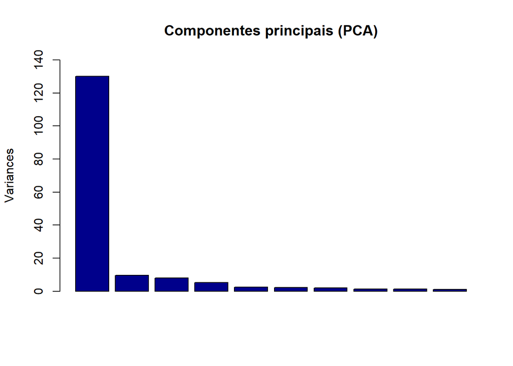

```r
plot(pca, ylim=c(0, 140), main ="Componentes principais (PCA)", col = "darkblue")
```

A visualização gráfica do PCA confirmou a análise anterior sobre a variabilidade, revelando que a maior parte da mesma é explicada pelo primeiro componente principal.

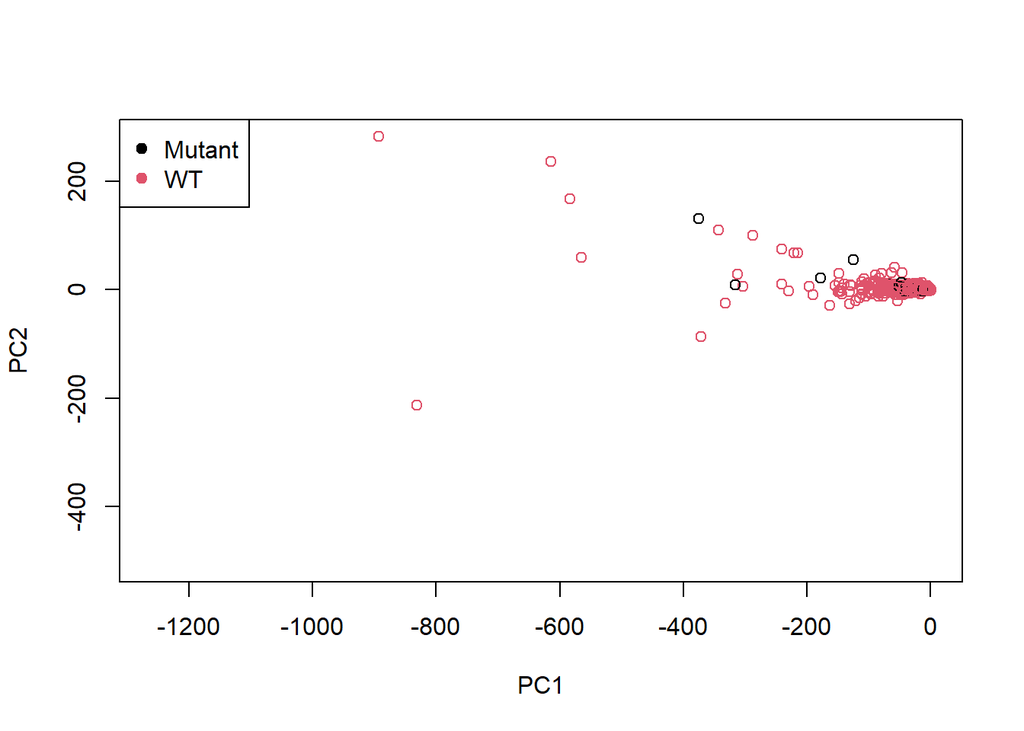

```r
plot(reduced_data[, 1], reduced_data[, 2], xlab = "PC1", ylab = "PC2",  col = as.integer(meta_gbm$paper_IDH.status, pch=19))
legend("topleft", legend = levels(meta_gbm$paper_IDH.status), col =1:length(levels(meta_gbm$paper_IDH.status)), pch = 19)
```

Neste gráfico de dispersão dos dados reduzidos, vemos as duas primeiras componentes principais e a distribuição dos pontos coloridos de acordo com a variável meta_gbm$paper_IDH.status. Após análise, verificamos que não existe uma boa separação e homogeneidade dos dados.

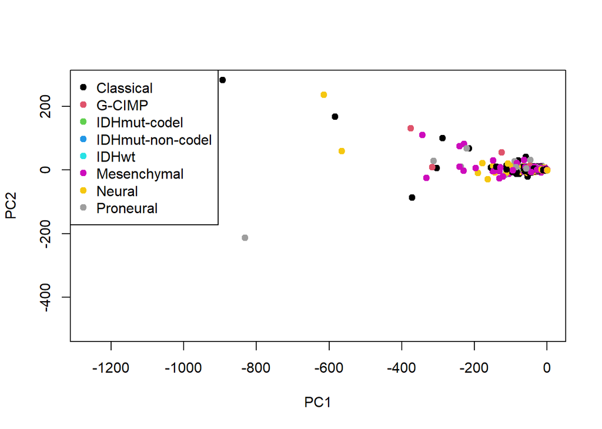

```r
plot(reduced_data[, 1], reduced_data[, 2], xlab = "PC1", ylab = "PC2",  col = as.integer(meta_gbm$paper_Original.Subtype), pch=19)
legend("topleft", legend = levels(meta_gbm$paper_Original.Subtype), col =1:length(levels(meta_gbm$paper_Original.Subtype)), pch = 19)
```

Tal como observado anteriormente, para a variável meta_gbm$paper_Original.Subtype, também não existe uma boa separação e homogeneidade dos dados.

```r
rot = pca$rotation
```

Os valores na matriz de rotação indicam a contribuição relativa de cada gene para cada componente principal.

## 9.2 SVD

A SVD (Decomposição em Valores Singulares) é um método algébrico de fatorização de matrizes amplamente utilizado na análise de dados para reduzir a dimensionalidade dos dados. A PCA (Análise de Componentes Principais) é um caso particular da SVD e é recomendada como um dos métodos para calcular a PCA.

```r
svd_res = svd(scale(gbm_assay))
```

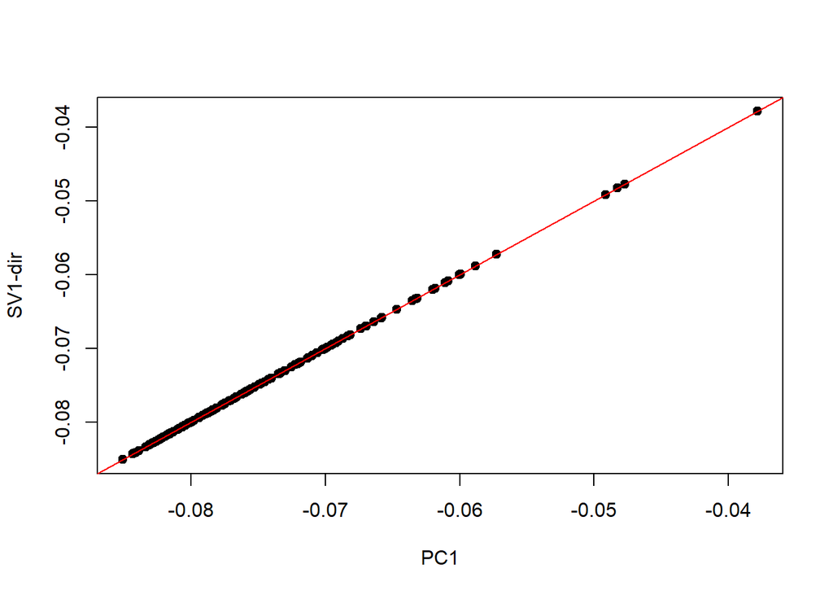

```r
plot(pca$rotation[,1], svd_res$v[,1], pch=19, xlab="PC1", ylab="SV1-dir") #como era de esperar
abline(0,1, col="red")
```

O gráfico resultante mostra a relação entre os vetores de rotação da primeira componente principal do PCA e os vetores singulares direitos da primeira componente singular do SVD. Espera-se que haja uma relação positiva entre esses vetores, uma vez que ambos descrevem informações importantes sobre a estrutura dos dados. A linha diagonal vermelha adicionada ao gráfico representa uma relação linear perfeita entre esses vetores.Em suma, as colunas de v são equivalentes aos loadings resultantes da PCA.

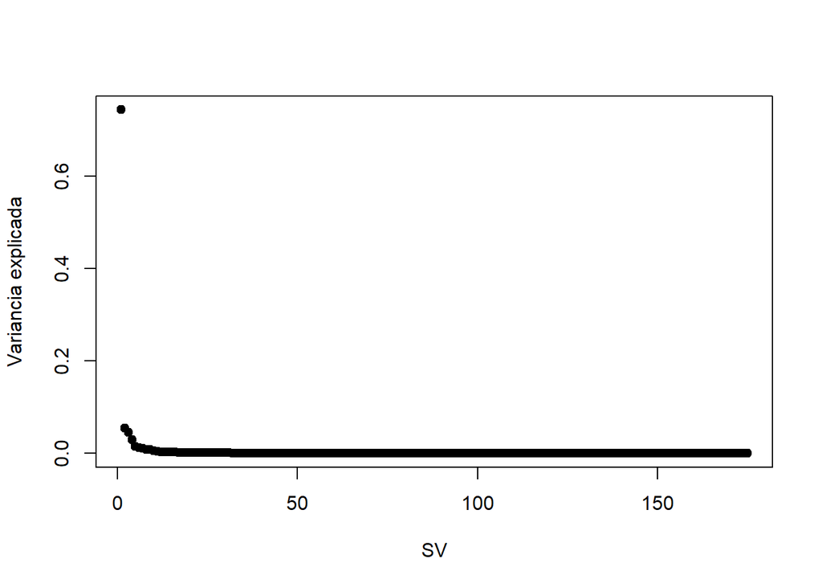

```r
plot(svd_res$d^2/sum(svd_res$d^2),pch=19,xlab="SV",ylab="Variancia explicada") #primeiro explica muito - 0.74 ou o ca
```

A visualização gráfica do PCA confirmou a análise anterior sobre a variabilidade, revelando que a maior parte da mesma é explicada pelo primeiro componente principal.

# 10 Clustering

```r
topgenes = rowttests(as.matrix(gbm_assay))
rank_topgenes = order(topgenes$p.value)
genes = rank_topgenes[1:25]
gbm_assay_rank = as.matrix(gbm_assay)[genes,]
```

```r
dist_matrix = dist(gbm_assay_rank, method = "euclidean")

dist_matrix1 = dist(gbm_assay_rank, method = "manhattan")

dist_matrix2 = dist(gbm_assay_rank, method = "minkowski")
```

```r
h_euc_comp = hclust(dist_matrix, method = "complete")
h_man_comp = hclust(dist_matrix1, method = "complete")
h_mink_comp = hclust(dist_matrix2, method = "complete")
```

## 10.1 Representação gráfica do clustering hierárquico do método “complete”

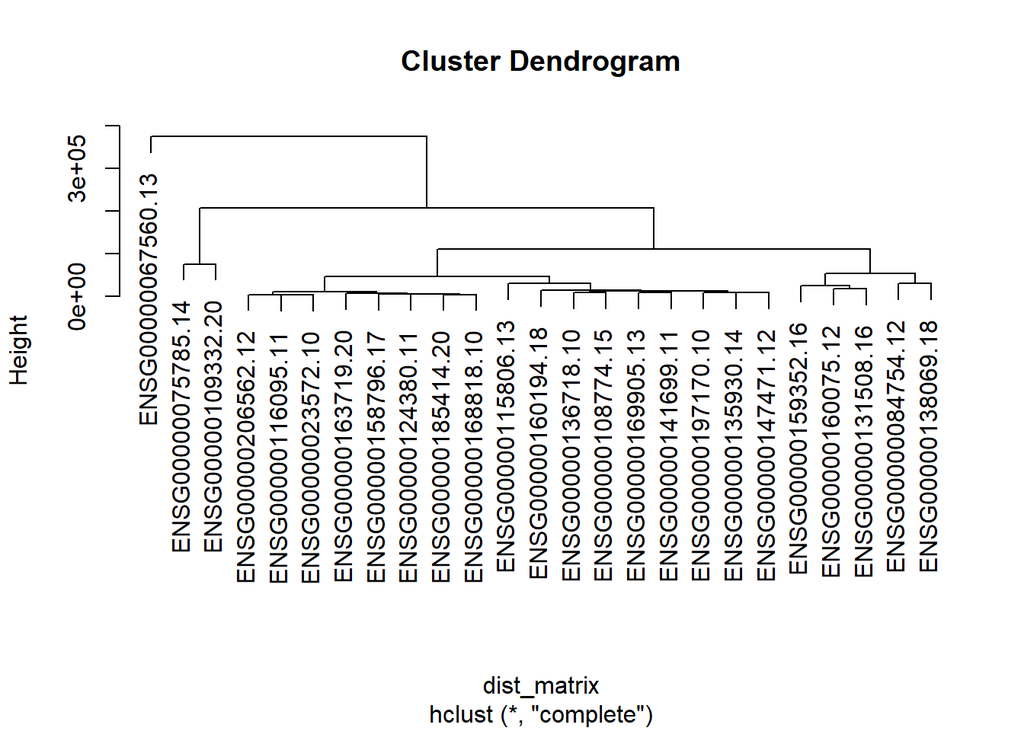

```r
plot(h_euc_comp)
```

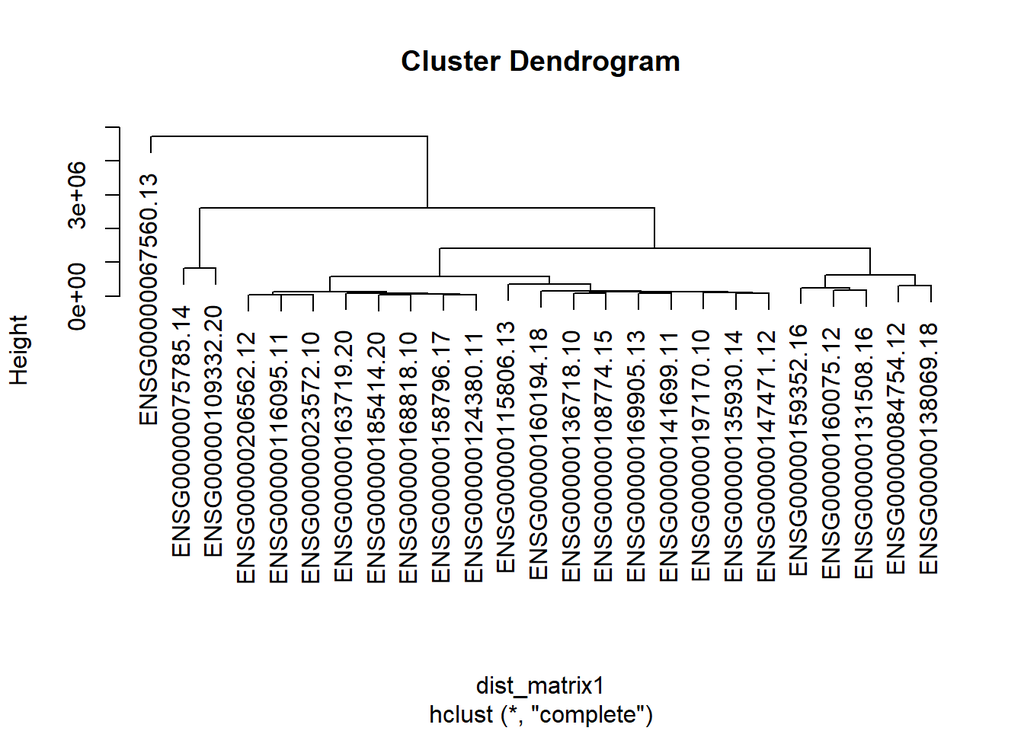

```r
plot(h_man_comp)
```

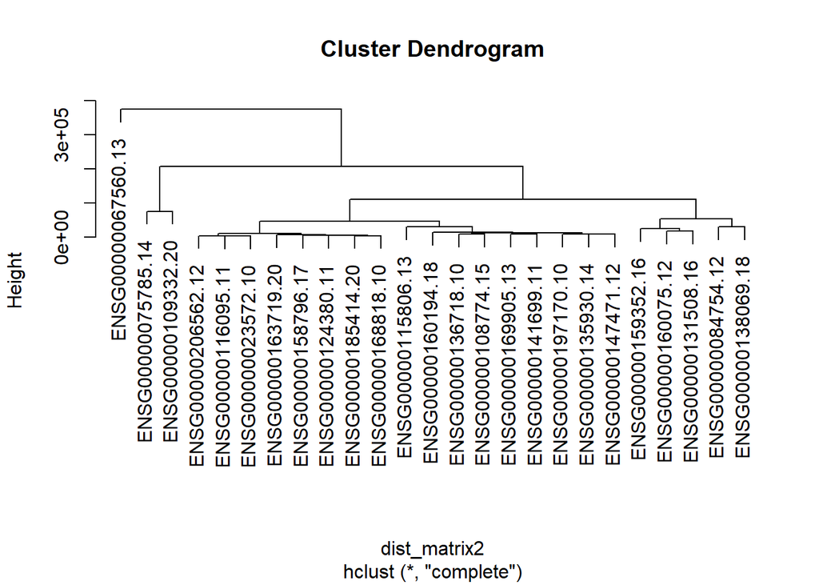

```r
plot(h_mink_comp)
```

```r
h_euc_sing = hclust(dist_matrix, method = "single")
h_man_sing = hclust(dist_matrix1, method = "single")
h_mink_sing = hclust(dist_matrix2, method = "single")
```